# Auffrischungskurs Statistik in R

Dr. Sascha Meyen

Experimentelle Kognitionswissenschaft | Fachbereich Informatik | Universität Tübingen

2024-01-14-09-41

Eine kurze Zusammenfassung der wichtigstens Inhalte von Statistik in R von Sascha Meyen (saschameyen@gmail.com).

# 1 Hypothesentests

## 1.1 Zufallsvariablen

Auch wenn es erstmal abstrakt wirkt, sind wir an Zufallsvariablen interessiert. Zum Beispiel wollen wir wissen, welche Gesundheitsverbesserung ein Medikament für einen neuen Patienten bringt. Die Gesundheitsverbesserung ist eine Zufallsvariable. Denn es ist nicht gewiss, welches Ergebnis es bei jedem Patienten bringt.

$$\text{Zufallsvariable } X$$

Das ist konzeptionell wie ein Würfelwurf, der auch eine Zufallsvariable ist. Wir stellen uns also erstmal beispielhaft vor, das Medikament bringt eine Gesundheitsverbesserung so wie ein Würfelwurf eine Zahl wirft.

## 1.2 Erwartungswert

Wir wissen wie gesagt nicht, was im Einzelfall passieren wird, aber wir können berechnen, was ein in Erwartung passt: Beim Würfel ist der Erwartungswert

$$E(X) = \sum_{x} xf(x) = 1 \cdot \frac{1}{6} + 2 \cdot \frac{1}{6} +
\ldots + 6 \cdot \frac{1}{6} = 3.5 ~\text{.}$$

Für später: Die Varianz und Standardabweichung sind

$$\begin{align*}
Var(X) & = \sum_{x} f(x) (x - E(X))^2 = \frac{1}{6}(1-3.5)^2 +
\ldots + \frac{1}{6} (6 - 3.5)^2 = 2.92 \text{ und }\\
SD(X) & = \sqrt{Var(X)} = \sqrt{2.92} = 1.71 ~\text{.}
\end{align*}$$

Diesen Erwartungswert kennen wir beim Würfel aber nicht beim Medikament. Das wollen wir ja gerade herausfinden. Wir tuen das, indem wir eine Untersuchung mit Patienten anlegen, ihnen das Medikament geben und dann den Mittelwert der Effekte berechnen. Wenn wir einen Würfel zum Beipspiel 30 Mal werfen, bekommen wir,

$$\frac{1}{N} \sum_{i = 1}^N X_i = \frac{1}{30} (4 + 4 + 6 + 1 + ...) =
3.73$$

```r
set.seed(2024-01-03)
x <- sample(1:6, 30, replace = TRUE)
m <- mean(x)
```

Das ist schon relativ nah am Erwartungswert, aber wie genau hängt der Mittelwert mit dem Erwartungswert zusammen?

$$E(X) = \sum_{x} x f(x) ~~~~\text{vs.}~~~~ \bar{X}_N = \frac{1}{N}
\sum_{i = 1}^N X_i$$

## 1.3 Zusammenhang zum beobachtbaren Mittelwert

Um einen Zusammenhang herzustellen, brauchen wir eine zentrale Annahme: Wir müssen annehmen, dass die einzelnen Beobachtungen (die Werte der einzelnen Patienten) $X_i$s alle aus dem gleichen Zufallsmechanismus stammen (z.B. alle kriegen die gleiche Menge des Medikaments) und unabhängig voneinander sind (wir ziehen Probanden zufällig und nicht nur Leute aus der gleichen Familie).

Diese zentrale Annahme ist, dass die einzelnen Beobachtungen unabhängig und identisch verteilt sind ($iid$, independently and indentically distributed) und man schreibt $X_1, ..., X_N \overset{iid}{\sim} X$. Das ist der Fall wenn wir $N$ Mal den gleichen Würfel werfen. Dann können wir mit den Rechenregeln für Zufallsvariabeln Folgendes herleiten.

$$E(\bar{X}_N) = E\left( \frac{1}{N} \sum_{i=1}^N X_i \right) =
\frac{1}{N} \sum_{i=1}^N E\left( X_i \right) = \frac{1}{N} \sum_{i=1}^N
E\left( X \right) = E(X)$$

$$Var(\bar{X}_N) = Var\left( \frac{1}{N} \sum_{i=1}^N X_i \right) =
\frac{1}{N^2} \sum_{i=1}^N Var\left( X_i \right) = \frac{1}{N}
\sum_{i=1}^N Var\left( X \right) = \frac{1}{N}Var(X)$$

$$SEM = SD(\bar{X}_N) = \sqrt{Var(\bar{X}_N)} =
\sqrt{\frac{1}{N}Var(X)} = \frac{SD(X)}{\sqrt{N}}$$

Außerdem gilt nach dem zentralen Grenzwertsatz, dass der Mittelwert normalverteilt ist. (Details: https://saschameyen.com/pdfs/Central-Limit-Theorem.html)

$$\lim_{N\rightarrow \infty} \bar{X}_N \sim \mathcal{N}$$

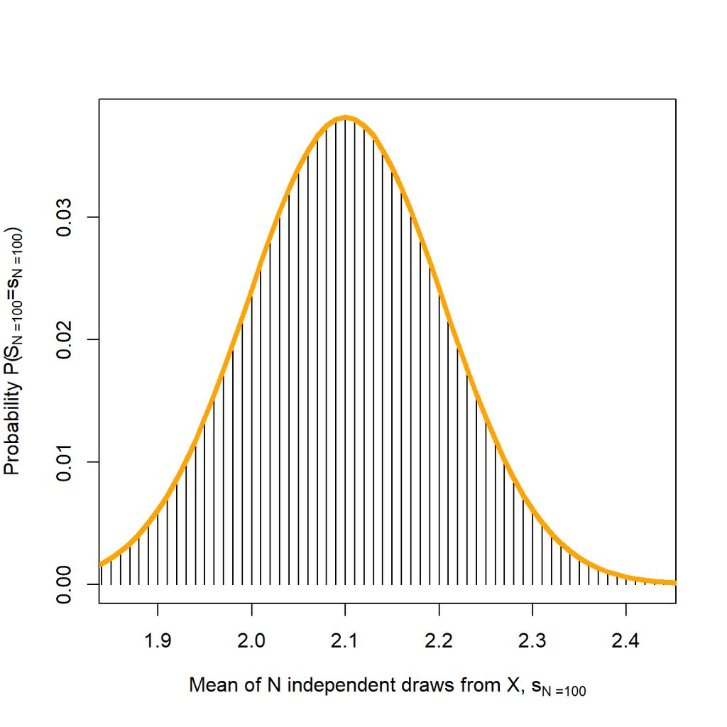

```r
# Convolution functions --------------------------------------------------------

# Convolve to get the distribution of the sum of X + Y
convolve_two_random_variables <- function(X, Y)
{
  X_matrix <- matrix(rep(X$outcome, nrow(Y)),
                     nrow = nrow(X), ncol = nrow(Y))
  Y_matrix <- matrix(rep(Y$outcome, nrow(X)),
                     nrow = nrow(X), ncol = nrow(Y), byrow = T)

  sum_matrix         <- X_matrix + Y_matrix
  probability_matrix <- X$probability %o% Y$probability

  Z <- aggregate(list(probability = c(probability_matrix)),
                 by = list(outcome = c(sum_matrix)),
                 sum)
  Z
}

# Get the distribution of X1 + X2 + ... + XN
get_n_times_convolved_random_variable <- function(N, X)
{
  S <- data.frame(outcome = 0, probability = 1)

  for (i in 1:N)
  { S <- convolve_two_random_variables(S, X) }

  S$outcome <- S$outcome/N
  S
}


# Random variables -------------------------------------------------------------

# Six sided die
X <- data.frame(outcome = 1:6, probability = rep(1/6, 6))

# Geometric distribution
X <- data.frame(outcome = 0:100, probability = dgeom(0:100, prob = 0.8))

# Pizza distribution
X <- data.frame(outcome = c(1, 2, 3, 4), probability = c(0.4, 0.2, 0.3, 0.1))


# Visualize --------------------------------------------------------------------

N <- 100
M <- get_n_times_convolved_random_variable(N, X)
xlim <- c(M$outcome[min(which(cumsum(M$probability) > .01))],
          M$outcome[max(which(cumsum(M$probability) < .999))+1])

# Plot mean distribution
plot(M,
     type = 'h',
     xlab = bquote('Mean of N independent draws from X, '*s["N ="*.(N)]),
     ylab = bquote('Probability P('*S["N ="*.(N)]*'='*s["N ="*.(N)]*')'),
     xlim = xlim)

# Add normal distribution with corresponding expected value and variance
E   <- sum(X$probability * X$outcome)
Var <- sum(X$probability * (X$outcome - E)^2 ) / N
f   <- dnorm(M$outcome, E, sqrt(Var))
points(M$outcome, f/sum(f),
       type = 'l', col = 'orange', lwd = 4)
```

Das ist fast alles, was wir wissen müssen.

Damit ist der Mittelwert für große Stichproben (Daumenregeln $N\geq30$) um den gesuchten Erwartungswert mit Normalverteilung verteilt und hat eine Standardabweichung — genannt standard error of the mean, SEM — die kleiner wird, je größer $N$ ist.
$$\bar{X}_N \overset{a}{\sim}\mathcal{N}\left(E(X), SEM^2 \right)
\\[1cm]$$

## 1.4 $z$-Test

Jetzt können wir für einen Mittelwert entscheiden, ob er plausiblerweise aus einem normalen Würfel entstanden ist oder nicht. Wenn es sich um einen gewöhnlichen Würfel handelt (Nullhypothese), dann gilt:

$$\text{Nullhypothese:}~\bar{X}_{N=30} \sim \mathcal{N}\left(3.5, \left(
\frac{1.71}{\sqrt{30}} \right)^2 \right)$$

Für einen beobachteten Mittelwert können wir dann die Wahrscheinlichkeit berechnen, diesen oder einen noch weiter abweichenden Wert zu finden. Diese Wahrscheinlichkeit nennen wir $p$-Wert.

$$p\text{-Wert} = P(\text{Beobachteter oder noch weiter abweichender
Mittelwert} \mid \text{Nullhypothese})$$

Im Beispiel mit $\bar{X}_N = 3.73$ ist das $p = .461$, was wir durch `2 * (1 - pnorm(3.73, mean = 3.5, sd = 1.71/sqrt(30)))` erhalten. Für einen Mittelwert von $\bar{X}_{N=30} = 4.2$ wäre dieser $p$-Wert kleiner, $p = .025$.

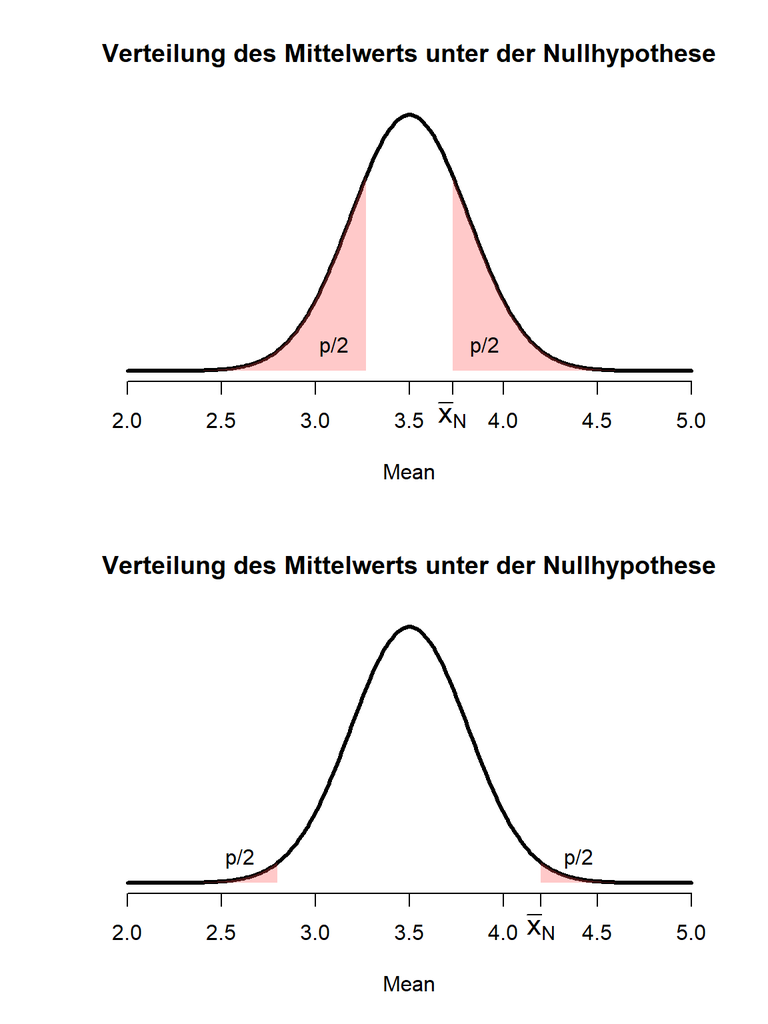

```r
par(mfrow = c(2, 1))

# Sample
N <- 30   # Number of observations, also called sample size
M <- 3.73 # Mean or average value of the observations

# Random variable X
E   <- 3.5        # Expected value: This is our hypothesis we want to test
Var <- 35/12      # Variance of the individual observations
SD  <- sqrt(Var)  # Standard deviation of the individual observations
SEM <- SD/sqrt(N) # Standard error = standard deviation of the mean

# Distribution curve
x <- seq(2, 5, .01)
f <- dnorm(x, mean = E, sd = SEM)
plot(x, f,
     type = 'l',
     xlab = 'Mean', yaxt = 'n', ylab = '',
     frame.plot = F,
     xlim = c(min(x), max(x)), lwd = 3,
     main = 'Verteilung des Mittelwerts unter der Nullhypothese')

# Visualize p value
xcol   <- seq(M, 6, .001)
fcol   <- dnorm(xcol, mean = E, sd = SEM)
redCol <- rgb(1,.3,.3,.3)
polygon(c(xcol, rev(xcol)),
        c(fcol*0, rev(fcol)),
        col = redCol, border = NA)
text(3.9, .125, "p/2", xpd = T)

xcol   <- seq(0, E + (E - M), .001)
fcol   <- dnorm(xcol, mean = E, sd = SEM)
redCol <- rgb(1,.3,.3,.3)
polygon(c(xcol, rev(xcol)),
        c(fcol*0, rev(fcol)),
        col = redCol, border = NA)
text(3.1, .125, "p/2", xpd = T)

# Mean on x-axis
axis(1, at = M, label = expression(bar(x)[N]), cex.axis = 1.3)

# Compute p value
p <- 2*(1 - pnorm(M, mean = E, sd = SEM))

#  -----------------------------------------------------------------------------

# Sample
N <- 30   # Number of observations, also called sample size
M <- 4.2  # Mean or average value of the observations

# Random variable X
E   <- 3.5        # Expected value: This is our hypothesis we want to test
Var <- 35/12      # Variance of the individual observations
SD  <- sqrt(Var)  # Standard deviation of the individual observations
SEM <- SD/sqrt(N) # Standard error = standard deviation of the mean

# Distribution curve
x <- seq(2, 5, .01)
f <- dnorm(x, mean = E, sd = SEM)
plot(x, f,
     type = 'l',
     xlab = 'Mean', yaxt = 'n', ylab = '',
     frame.plot = F,
     xlim = c(min(x), max(x)), lwd = 3,
     main = 'Verteilung des Mittelwerts unter der Nullhypothese')

# Visualize p value
xcol   <- seq(M, 6, .001)
fcol   <- dnorm(xcol, mean = E, sd = SEM)
redCol <- rgb(1,.3,.3,.3)
polygon(c(xcol, rev(xcol)),
        c(fcol*0, rev(fcol)),
        col = redCol, border = NA)
text(4.4, .125, "p/2", xpd = T)

xcol   <- seq(0, E + (E - M), .001)
fcol   <- dnorm(xcol, mean = E, sd = SEM)
redCol <- rgb(1,.3,.3,.3)
polygon(c(xcol, rev(xcol)),
        c(fcol*0, rev(fcol)),
        col = redCol, border = NA)
text(2.6, .125, "p/2", xpd = T)

# Mean on x-axis
axis(1, at = M, label = expression(bar(x)[N]), cex.axis = 1.3)
```

```r
# Compute p value
p <- 2*(1 - pnorm(M, mean = E, sd = SEM))
```

Wir legen uns vor dem Experiment auf einen Wert fest, ab dem wir sagen, dass $p$ zu klein ist und wir deshalb daran zweifeln, dass $E(X) = 3.5$ tatsächlich der Fall ist. Diesen Wert nennen wir das $\alpha$-Niveau (Alpha-Niveau) oder Signifikanzniveau.

$$\text{Signifikanzniveau}~\alpha$$

- Wenn $p < \alpha$: Wir lehnen die Nullhypothese ab. Es liegt Evidenz gegen die Nullhypothese vor.
- Wenn $p \geq \alpha$: Wir lehnen die Nullhypothese nicht ab. Es liegt keine Evidenz gegen die Nullhypothese vor (aber auch keine definitive Evidenz für die Nullhypothese).

## 1.5 $t$-Tests

Den $z$-Test wenden wir in der Praxis nicht an, weil wir fast nie wissen, was die wahre Varianz der Beobachtungen $Var(X)$ ist. Stattdessen schätzen wir die Varianz aus der Stichprobe mit $S_{N}^2 = \frac{1}{N-1} \sum_{i=1}^N (X_i - \bar{X}_N)^2$, um damit den Standardfehler zu bestimmen:

$$SEM = \frac{SD(X)}{\sqrt{N}} ~~~ \overset{\text{in der
Praxis}}{\longrightarrow} ~~~ SEM = \frac{S_{N}}{\sqrt{N}} .$$

Wir müssen dafür korrigieren, dass wir den SEM schätzen, denn sonst sind wir uns in unseren Aussagen zu sicher. Dafür ersetzen wir die Normalverteilung ($z$) mit der $t$-Verteilung, die im sozusagen die Rolle der Normalverteilung mit geschätzter Varianz einnimmt.

In der Realität kennen wir auch den Erwartungswert nicht. Über diesen wollen wir ja gerade einen Hypothesentest durchführen. Deshalb ersetzen wir ihn durch unseren hypothetisierten Erwartungwert $\mu_0$:

$$E(X) ~~~ \overset{\text{in der Praxis}}{\longrightarrow} ~~~ \mu_0 .$$

### 1.5.1 Eine Stichprobe

Wir haben eine Stichprobe von $N=30$ Patienten. Bei jedem Patienten wurde erhoben, ob es ihm nach Medikamenteinnahme besser ging, $X_i$. Wir erhalten aus der Stichprobe den Mittelwert $\bar{X}_{N=30} = 1$ und die Standardabweichung $S_{N=30} = 2.38$. Wir testen nun die Hypothese, dass das Medikament in Erwartung keine Verbesserung bringt, Nullhypothese: $\mu_0 = 0$.

```r
# Simulate sample with a certain mean and standard deviation
simulate_sample <- function(N, M, S)
{
  x <- rnorm(N)
  x <- ( x - mean(x) ) / sd(x) # z transformation
  x <- x*S + M # Transform to desired mean and standard deviation
  x
}

# Simulate
x <- simulate_sample(N = 30, M = 1, S = 2.38)
# mean(x) # 1
# sd(x) # 2.38

# Conduct one-sample t test
t.test(x, mu = 0)
```

```
##
##  One Sample t-test
##
## data:  x
## t = 2.3014, df = 29, p-value = 0.02875
## alternative hypothesis: true mean is not equal to 0
## 95 percent confidence interval:
##  0.1112934 1.8887066
## sample estimates:
## mean of x
##         1
```

Als Ergebnis erhalten wir, dass es unwahrscheinlich ist (unwahrscheinlicher als das Signifikanzniveau von $\alpha = 5\%$), diesen Mittelwert zu beobachten, wenn das Medikament in Wahrheit keinen Effekt hat (wenn $E(X) = \mu_0 = 0$ wäre). Wir sprechen von einem “signifikanten” Ergebnis — signifikant im Sinne von “eindeutig” oder “überzufällig” von der Nullhypothese abweichend. Deshalb lehnen wir die Nullhypothese, dass das Medikament nicht wirkt, ab. Wir schreiben in einem wissenschaftlichen Bericht:

> The treatment was effective with a mean score of $M=1$ ($SD = 2.38$), $t(29) = 2.3$, $p = .029$, $95\%\text{ CI }[0.11, 1.89]$.

Der $t$-Wert ist, wieviele Standardfehler der Mittelwert von der Nullhypothese entfernt liegt. Hier ist der Standardfehler $SEM = \frac{2.38}{\sqrt{30}} = 0.44$ und $\bar{X}_{N=30} = 1$ ist genau $t=2.3$ viele $SEM = 0.44$ Schritte von $\mu_0 = 0$ entfernt.

$$t = \frac{\bar{X}_N - \mu_0}{SEM}$$

Die Zahl 29 zum $t$-Wert bezeichnet die Freiheitsgrade. Im Einstichprobenfall sind die Freiheitsgrade $df = N-1$. Es ist eine technische Größe, die dafür benötigt wird, die $t$-Verteilung korrekt zu berechnen. Außerdem geben wir das $(1-\alpha)$ Konfidenzintervall an.

### 1.5.2 Zwei unabhängige Stichproben mit gleicher Varianz

Bis jetzt hatten wir den einfachen Fall, dass wir eine Stichprobe mit $N$ Werten hatten, $X_1$, …, $X_N$. Jetzt betrachten wir den Fall, dass wir zwei Reihen von Werten haben, $X_1$, …, $X_N$ und $Y_1$, …, $Y_M$. Das ist zum Beispiel der Fall, wenn wir die Effektivität von eines Medikaments mit dem Placebo vergleichen wollen. In Gruppe 1 ($X$) gibt es ein Placebo und in Gruppe 2 ($Y$) gibt es das Medikament. Die Frage ist jetzt, ob es zwischen den beiden Gruppen einen Unterschied hinsichtlich der Effektivität gibt.

Hier gibt es jetzt eine Fallunterscheidung: Nehmen wir an, dass die zugrundeliegende Varianz in beiden Gruppen gleich ist, $Var(X) = Var(Y)$, dann testen wir wie folgt und die Freiheitsgrade sind $df = N_X + N_Y - 2$. (Beachte: Nur weil die zugrundeliegenden Varianzen gleich sind, müssen nicht die beobachteten, zufallsbehafteten Stichprobenvarianzen gleich sein.)

```r
x <- simulate_sample(N = 20, M = 0.2, S = 1.9)
y <- simulate_sample(N = 35, M = 1,   S = 2.38)

t.test(y, x, mu = 0, var.equal = TRUE)
```

```
##
##  Two Sample t-test
##
## data:  y and x
## t = 1.2857, df = 53, p-value = 0.2042
## alternative hypothesis: true difference in means is not equal to 0
## 95 percent confidence interval:
##  -0.4480729  2.0480729
## sample estimates:
## mean of x mean of y
##       1.0       0.2
```

> The treatment ($M=1$, $SD = 2.38$) was not provably more effective than the placebo ($M = 0.2$, $SD = 1.9$), with a difference of $M = 0.8$, $t(53) = 1.29$, $p = .204$, $95\%\text{ CI }[-0.45, 2.05]$.

### 1.5.3 Zwei unabhängige Stichproben mit ungleicher Varianz

Wenn wir nicht davon ausgehen, dass zwei Stichproben die gleiche Varianz haben (und das ist in den meisten Fällen so), dann testen wir wie folgt.

```r
x <- simulate_sample(N = 20, M = 0.2, S = 1.9)
y <- simulate_sample(N = 35, M = 1,   S = 2.38)

t.test(y, x, mu = 0, var.equal = FALSE)
```

```
##
##  Welch Two Sample t-test
##
## data:  y and x
## t = 1.3673, df = 47.16, p-value = 0.178
## alternative hypothesis: true difference in means is not equal to 0
## 95 percent confidence interval:
##  -0.3769608  1.9769608
## sample estimates:
## mean of x mean of y
##       1.0       0.2
```

> The treatment ($M=1$, $SD = 2.38$) was not provably more effective than the placebo ($M = 0.2$, $SD = 1.9$), with a difference of $M = 0.8$, $t(47.2) = 1.37$, $p = .178$, $95\%\text{ CI }[-0.38, 1.98]$.

Die Freiheitsgrade werden hier kleiner, je mehr die Varianz der Stichproben abweicht. Das liegt daran, dass im Extremfall eine Stichprobe gar keine Varianz hat. Dann ist es fast so wie ein Einstichprobenfall, weil ein fester Wert (aus der Stichprobe ohne Varianz) gegen die andere Stichprobe verglichen wird.

Die Freiheitsgrade berechnen sich in diesem Fall wie folgt.

$$df = \frac{\left(\frac{s^2_1}{N_1} +
\frac{s^2_2}{N_2}\right)^2}{\frac{s^4_1}{N_1^2(N_1-1)} +
\frac{s^2_4}{N_2^2(N_2-1)}}$$

### 1.5.4 Zwei abhängige Stichproben

Wenn wir zwei Reihen von Werten haben, die aber paarweise zusammengehören, ($X_1$, $Y_1$), …, ($X_N$, $Y_N$), dann bilden wir Differenzen, $D_1 = Y_1 - X_1$, …, $D_N = Y_N - X_N$ und verfahren wie im Einstichprobenfall. Der Vorteil: Variabilität zwischen den Versuchspersonen wird rausgerechnet oder “kontrolliert”.

```r
set.seed(2024-01-03)
x <- simulate_sample(N = 35, M = 0.2, S = 1.9)
y <- x + simulate_sample(N = 35, M = 0.8, S = sqrt(2.38^2 - 1.9^2 + 0.62))
# mean(y) # 1
# sd(y)   # 2.38

d <- y - x
# mean(d) # 0.8
# sd(d)   # 1.64
t.test(d, mu = 0)
```

```
##
##  One Sample t-test
##
## data:  d
## t = 2.8941, df = 34, p-value = 0.006595
## alternative hypothesis: true mean is not equal to 0
## 95 percent confidence interval:
##  0.2382344 1.3617656
## sample estimates:
## mean of x
##       0.8
```

```r
# Alternatively:
t.test(y, x, paired = T)
```

```
##
##  Paired t-test
##
## data:  y and x
## t = 2.8941, df = 34, p-value = 0.006595
## alternative hypothesis: true mean difference is not equal to 0
## 95 percent confidence interval:
##  0.2382344 1.3617656
## sample estimates:
## mean difference
##             0.8
```

> Participants’ health improved after taking the medication ($M = 0.8$, $SD = 1.64$), $t(34) = 2.89$, $p = .007$, $95\%\text{ CI }[0.24, 1.36]$.

# 2 Konfidenzintervalle

Das Problem von Hypothesentests mit $p$-Werten ist, dass die Nullhypothese $\mu_0 = 0$ abgelehnt werden kann, egal wie groß der Effekt des Medikaments ist. Kleine Effekte werden immer signifikant, wenn die Stichprobe nur groß genug ist.

```r
x <- simulate_sample(N = 30000000, M = 0.001, S = 2.38)
t.test(x)
```

```
##
##  One Sample t-test
##
## data:  x
## t = 2.3014, df = 3e+07, p-value = 0.02137
## alternative hypothesis: true mean is not equal to 0
## 95 percent confidence interval:
##  0.0001483436 0.0018516564
## sample estimates:
## mean of x
##     0.001
```

> The treatment was effective with a mean score of $M=0.001$ ($SD = 2.38$), $t(29999999) = 2.3$, $p = .021$, $95\%\text{ CI }[0.0001, 0.0019]$.

Das Konfidenzintervall gibt an, für welche Werte Nullhypothesenwerte $\mu_0$ der Hypothesentest nicht signifikant ist, also welche Erwartungswerte plausibel sind. Es ist wichtig, das Konfidenzintervall anzugeben, um einschätzen zu können, wie groß der Effekt des Medikaments ist. “Das Medikament ist nachweislich wirksam” ist weniger aussagekräftig als “Das Medikament hat nachweislich eine Wirksamkeit zwischen [0.0001, 0.0019]” oder “Das Medikament hat nachweislich eine Wirksamkeit zwischen [0.11, 1.89]”.

# 3 Beispieldatensatz

Jetzt beginnen wir die Übungsphase. Dafür betrachten wir einen simulierten, fiktiven Datensatz: Es gibt Patienten (männliche `sex_1 = 1` und weibliche `sex_0 = 1`), die drei Behandlungsmethoden durchlaufen haben (`placebo = 1`, `treatment_a = 1` und `treatment_b` = 1). Pro Behandlungsmethode gibt es eine Vorher- (`pre = 1`) und eine Nachher-Messung (`post = 1`). Jeweils wurde der Gesundheitsstatus gemessen (`health`). Wir interessieren uns jetzt erstmal nicht für die Validität der Untersuchung (ob die Gesundheitsmessung sinnvoll war oder ob zwischen den Behandlungsmethoden genug Zeit vergangen ist), sondern uns interessiert nur die statistische Auswertung.

Die Aufgabe besteht nun darin, etwas über die Einflüsse auf Gesundheit herauszufinden.

- Sind Männer insgesamt gesünder als Frauen?
- Haben Placebos einen Effekt?
- Hat Behandlung A einen Effekt? Geht dieser Effekt über den Placeboeffekt hinaus?
- Hat Behandlung B einen Effekt? Geht dieser Effekt über den Placeboeffekt hinaus?
- Hat Behandlung B einen Effekt für Frauen?

Wir werden erst am Ende aufdecken, welche wahren Effekte der Simulation zugrunde liegen.

Als Starthilfe ist hier ein Beispiel für die Frage: “Sind Männer nach der Behandlung B gesünder als vorher?”

```r
# Load data
dat <- read.table("simulated_health_dat.csv")

# Get an overview
# head(dat)
# summary(dat)

# Effect of treatment B for men
men_B_dat <- dat[dat$sex_1 == 1 & dat$treatment_b == 1, ]
men_B_mean_dat <- aggregate(data = men_B_dat,
                            health ~ part_id * post,
                            mean)

# Get one effect for each male participant
men_B_post   <- men_B_mean_dat$health[men_B_mean_dat$post == 1]
men_B_pre    <- men_B_mean_dat$health[men_B_mean_dat$post == 0]
men_B_effect <- men_B_post - men_B_pre

# Hypothesis test
t.test(men_B_effect, mu = 0)
```

```
##
##  One Sample t-test
##
## data:  men_B_effect
## t = 6.116, df = 49, p-value = 1.55e-07
## alternative hypothesis: true mean is not equal to 0
## 95 percent confidence interval:
##  0.5935038 1.1743880
## sample estimates:
## mean of x
## 0.8839459
```

**Lösungen**

```r
# Load data
dat <- read.table("simulated_health_dat.csv")

# Generally: Men healthier than women? ----------------------------------------
sex_dat <- aggregate(data = dat,
                     health ~ part_id * sex_0,
                     mean)

t.test(sex_dat$health[sex_dat$sex_0 == 0],
       sex_dat$health[sex_dat$sex_0 == 1])
```

```
##
##  Welch Two Sample t-test
##
## data:  sex_dat$health[sex_dat$sex_0 == 0] and sex_dat$health[sex_dat$sex_0 == 1]
## t = -5.5743, df = 83.745, p-value = 2.962e-07
## alternative hypothesis: true difference in means is not equal to 0
## 95 percent confidence interval:
##  -0.8622596 -0.4087973
## sample estimates:
## mean of x mean of y
##  4.929953  5.565481
```

```r
# Placebo: effect? ------------------------------------------------------------
placebo_dat <- aggregate(data = dat[dat$placebo == 1, ],
                         health ~ part_id * post,
                         mean)

placebo_effects <- placebo_dat$health[placebo_dat$post == 1] -
                   placebo_dat$health[placebo_dat$post == 0]
t.test(placebo_effects)
```

```
##
##  One Sample t-test
##
## data:  placebo_effects
## t = 1.2189, df = 90, p-value = 0.2261
## alternative hypothesis: true mean is not equal to 0
## 95 percent confidence interval:
##  -0.06300697  0.26306320
## sample estimates:
## mean of x
## 0.1000281
```

```r
# Treatment A: effect? --------------------------------------------------------
treatment_A_dat <- aggregate(data = dat[dat$treatment_a == 1,],
                             health ~ part_id * post,
                             mean)

effects_A <- treatment_A_dat$health[treatment_A_dat$post == 1] -
             treatment_A_dat$health[treatment_A_dat$post == 0]
t.test(effects_A)
```

```
##
##  One Sample t-test
##
## data:  effects_A
## t = 14.826, df = 90, p-value < 2.2e-16
## alternative hypothesis: true mean is not equal to 0
## 95 percent confidence interval:
##  1.118054 1.464059
## sample estimates:
## mean of x
##  1.291056
```

```r
# Treatment A: effect larger than placebo effect? -----------------------------
effect_A_beyond_placebo <- effects_A - placebo_effects
t.test(effect_A_beyond_placebo)
```

```
##
##  One Sample t-test
##
## data:  effect_A_beyond_placebo
## t = 9.5697, df = 90, p-value = 2.242e-15
## alternative hypothesis: true mean is not equal to 0
## 95 percent confidence interval:
##  0.9437705 1.4382860
## sample estimates:
## mean of x
##  1.191028
```

```r
# Treatment B: effect? --------------------------------------------------------
treatment_B_dat <- aggregate(data = dat[dat$treatment_b == 1,],
                             health ~ part_id * post,
                             mean)

effects_B <- treatment_B_dat$health[treatment_B_dat$post == 1] -
             treatment_B_dat$health[treatment_B_dat$post == 0]
t.test(effects_B)
```

```
##
##  One Sample t-test
##
## data:  effects_B
## t = 2.0959, df = 90, p-value = 0.0389
## alternative hypothesis: true mean is not equal to 0
## 95 percent confidence interval:
##  0.01322681 0.49432616
## sample estimates:
## mean of x
## 0.2537765
```

```r
# Treatment B: effect larger than placebo effect? -----------------------------
effect_B_beyond_placebo <- effects_B - placebo_effects
t.test(effect_B_beyond_placebo)
```

```
##
##  One Sample t-test
##
## data:  effect_B_beyond_placebo
## t = 1.0236, df = 90, p-value = 0.3088
## alternative hypothesis: true mean is not equal to 0
## 95 percent confidence interval:
##  -0.1446680  0.4521647
## sample estimates:
## mean of x
## 0.1537484
```

```r
# Treatment B: effect for women? ----------------------------------------------
women_B_dat <- dat[dat$sex_1 == 0 & dat$treatment_b == 1, ]
women_B_mean_dat <- aggregate(data = women_B_dat,
                              health ~ part_id * post,
                              mean)

women_B_post   <- women_B_mean_dat$health[women_B_mean_dat$post == 1]
women_B_pre    <- women_B_mean_dat$health[women_B_mean_dat$post == 0]
women_B_effect <- women_B_post - women_B_pre

t.test(women_B_effect, mu = 0)
```

```
##
##  One Sample t-test
##
## data:  women_B_effect
## t = -4.1837, df = 40, p-value = 0.0001523
## alternative hypothesis: true mean is not equal to 0
## 95 percent confidence interval:
##  -0.7633794 -0.2660663
## sample estimates:
##  mean of x
## -0.5147228
```

# 4 Entscheidungstheorie

## 4.1 Fehler 1. Art und Fehler 2. Art

Bei statistischen Tests treffen wir eine Entscheidung darüber, ob eine Hypothese wahr ist oder nicht. Je nach Wahrheit kann unsere Entscheidung richtig oder falsch sein. Im Allgemeinen gibt es vier Fälle, die sowohl unsere Entscheidung ($\hat{X}$) als auch die Wahrheit ($X$) berücksichtigen.

|  | $X=1$ | $X=0$ |
| --- | --- | --- |
| $\hat{X}=1$ | Hit | False Alarm |
| $\hat{X}=0$ | Miss | Correct Rejection |

Bei frequentistischen Tests nehmen wir eine Nullhypothese als wahr an und prüfen, ob sie mit den erhobenen Daten übereinstimmt. Wir definieren einen Ablehnungsbereich so, dass er der Wahrscheinlichkeit ($\alpha$) entspricht, mit der wir die Nullhypothese ablehnen, gegeben dass sie wahr ist. Infolgedessen könnten wir die Nullhypothese fälschlicherweise ablehnen, obwohl sie wahr ist, oder sie fälschlicherweise beibehalten, obwohl sie falsch ist.

|  | $H_0$ is false | $H_0$ is true |
| --- | --- | --- |
| $H_0$ ablehnen | Richtig | Fehler 1. Art |
| $H_0$ beibehalten | Fehler 2. Art | Richtig |

Diese beiden Arten von Fehlern nennen wir Fehler 1. Art und Fehler 2. Art (engl. *Type-I error* und *Type-II error*). Die Wahrscheinlichkeiten werden mit $\alpha$ und $\beta$ notiert.

**Fehler 1. Art und Fehler 2. Art**

Wahrscheinlichkeit für Fehler 1. Art:
$$\alpha = P(H_0 \text{ ablehnen wenn } H_0 \text{
ist wahr})$$

Wahrscheinlichkeit für Fehler 2. Art:
$$\beta = P(H_0 \text{ beibehalten wenn } H_0
\text{ ist falsch})$$

Um ein überzeugendes Experiment zu designen, muss man beide Fehlertypen berücksichtigen. Während man bei der Bestimmung von $\alpha$ der Konvention $\alpha \in \{.01, .05, .1\}$ folgen kann, ist es bei $\beta$ komplizierter.

## 4.2 Teststärke

Die Wahrscheinlichkeit, die Nullhypothese abzulehnen wenn sie falsch ist, wird als Teststärke (engl. *power*) bezeichnet.

**Teststärke**

$$\text{Teststärke}
= P(H_0 \text{ verwerfen wenn } H_0 \text{ ist falsch})
= 1 - \underbrace{P(H_0 \text{ beibehalten wenn } H_0 \text{ ist
falsch})}_{\text{P(Fehler 2. Art)} = \beta}
= 1 -\beta$$

### 4.2.1 Berechnung der Teststärke

Um die Teststärke eines Experiments mit gegebener Stichprobengröße zu berechnen, muss man von einer wahren Effektgröße (bzw. einem wahren Mittelwert) ausgehen.

Als Beispiel betrachten wir ein Experiment, in dem wir den Effekt einer speziellen Behandlung untersuchen. Eine Gruppe von $n=25$ Teilnehmern führt eine Aufgabe sowohl unter Kontroll- als auch unter Behandlungsbedingungen durch. Ihre Reaktionszeit (RT) wird gemessen. Die Differenzen der mittleren RTs werden für statistische Tests verwendet und können als normalverteilt angenommen werden. Zusätzlich nehmen wir an, dass die wahre Standardabweichung mit $\sigma = 150$ ms bekannt ist.

Um zu untersuchen, ob die Behandlung RTs beeinflussen, führen wir einen zweiseitigen $t$-Test durch, $H_0: \mu = \mu_0 = 0$ vs. $H_1: \mu \neq \mu_0$, mit einem Signifikanzniveau von $\alpha = .05$.

Für jetzt wissen wir, dass der wahre Effekt $\mu = 80$ ms sein sollte. Wie hoch ist die Wahrscheinlichkeit, in dem Experiment einen signifikanten Effekt zu beobachten, gegeben dass der wahre Effekt 80ms ist?

#### 4.2.1.1 Alternative 1: Analytische Berechnung

Für eine analytische Berechnung wäre eine Visualisierung hilfreich.

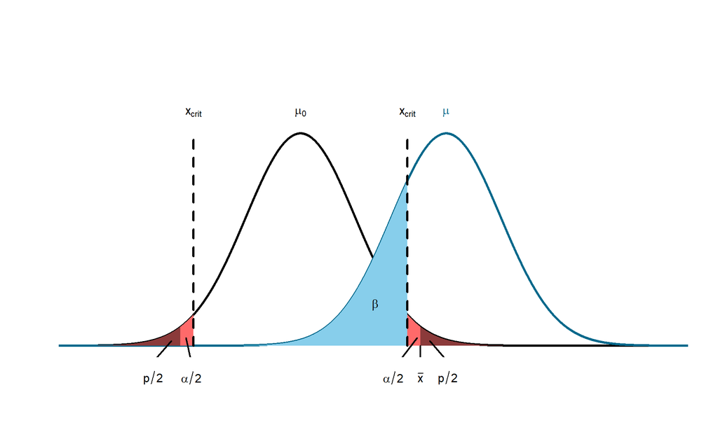

```r
# Given: mu_0 = 0, mu = 80, sigma = 150, n = 25
mu_0  <- 0
mu    <- 80
sigma <- 150
n     <- 25
alpha <- .05
se    <- sigma / sqrt(n)
M     <- mu_0 + 2.2 * se

# Distribution Curves
x <- seq(mu_0 - 5 * se, mu + 5 * se, .01)
f <- dnorm(x, mean = mu_0, sd = se)
plot(x, f, type = 'l', lwd = 3,
     axes = F, xlab = '', ylab = '',
     ylim = c(0, 1.3 * max(f)), xlim = c(mu_0 - 4 * se, mu + 4 * se))
g <- dnorm(x, mean = mu, sd = se)
points(x, g, type = 'l', col = "deepskyblue4", lwd = 3)

# Mark of Distributions
text(c(mu_0, mu), 1.1 * dnorm(mu_0, sd = se),
     expression(mu[0], mu), col = c("black", "deepskyblue4"))

# Right Rejection Area
xcol <- seq(qnorm(1-alpha/2, sd = se), mu_0 + 5 * se, .001)
fcol <- dnorm(xcol, mean = mu_0, sd = se)
polygon(c(xcol, rev(xcol)),
        c(fcol*0, rev(fcol)),
        col = "indianred1", border = NA)
text(mu_0 + 2.2 * se - 15, -.002, expression(alpha/2), xpd = T)
arrows(mu_0 + 2.2 * se - 2, 0.0005,
       mu_0 + 2.2 * se - 12, -0.001,
       code = 0, lwd = 2)

# Left Rejection Area
xcol <- seq(mu_0 - 5 * se, qnorm(alpha/2, sd = se), .001)
fcol <- dnorm(xcol, mean = mu_0, sd = se)
polygon(c(xcol, rev(xcol)),
        c(fcol*0, rev(fcol)),
        col = "indianred1", border = NA)
text(mu_0 - 2 * se, -.002, expression(alpha/2), xpd = T)
arrows(mu_0 - 2.1 * se, 0.0005,
       mu_0 - 2 * se, -0.001,
       code = 0, lwd = 2)

# Right P Value
xcol <- seq(M, mu_0 + 5 * se, .001)
fcol <- dnorm(xcol, mean = mu_0, sd = se)
polygon(c(xcol, rev(xcol)),
        c(fcol*0, rev(fcol)),
        col = "indianred4", border = NA, xpd = T)
text(M + 15, -.002, expression(p/2), xpd = T)
arrows(M + 5, 0.0003,
       M + 15, -0.001,
       code = 0, lwd = 2)

# Left P Value
xcol <- seq(mu_0 - 5 * se, -M, .001)
fcol <- dnorm(xcol, mean = mu_0, sd = se)
polygon(c(xcol, rev(xcol)),
        c(fcol*0, rev(fcol)),
        col = "indianred4", border = NA, xpd = T)
text(-M - 15, -.002, expression(p/2), xpd = T)
arrows(-M - 5, 0.0003,
       -M - 15, -0.001,
       code = 0, lwd = 2)

# Beta Area
xcol <- seq(qnorm(alpha/2, sd = se), qnorm(1-alpha/2, sd = se), .001)
gcol <- dnorm(xcol, mean = mu, sd = se)
polygon(c(xcol, rev(xcol)),
        c(gcol*0, rev(gcol)),
        col = "skyblue", border = NA)
text(mu - 1.3 * se, max(gcol)/4, expression(beta), xpd = T)

# Mark of Critical Values
arrows(qnorm(1-alpha/2, sd = se), 0,
       qnorm(1-alpha/2, sd = se), dnorm(mu_0, sd = se),
       lwd = 3, code = 0, lty = 2)
text(qnorm(1-alpha/2, sd = se), 1.1 * dnorm(mu_0, sd = se),
     expression(x[crit]))

arrows(qnorm(alpha/2, sd = se), 0,
       qnorm(alpha/2, sd = se), dnorm(mu_0, sd = se),
       lwd = 3, code = 0, lty = 2)
text(qnorm(alpha/2, sd = se), 1.1 * dnorm(mu_0, sd = se),
     expression(x[crit]))

# Mark of Data Point
text(M, -.002, expression(bar(x)), xpd = T)
arrows(M, 0,
       M, -0.001,
       code = 0, lwd = 2)
```

Der kritische und der beobachtete $X$-Wert können in einen kritischen und einen beobachteten $T$-Wert umgewandelt werden, mit dem wir die Teststärke berechnen können. Wenn der beobachtete $X$-Wert mehr auf der Seite der Alternative liegt als der kritische $X$-Wert (bzw. wenn der beobachtete $T$-Wert mehr auf der Seite der Alternative liegt als der kritische $T$-Wert), wird die Nullhypothese abgelehnt. Andernfalls sollte die Nullhypothese beibehalten werden.

Gegeben $\sigma=150$ und $n=25$, wir können den Standardfehler berechnen, $SE = \frac{\sigma}{\sqrt{n}} = \frac{150}{\sqrt{25}} = 30$. Der kritische $T$-Wert wird durch das Signifikanzniveau und die Stichprobengröße bestimmt, $t_{\text{krit}} = t_{.975}(24) = 2.07$. Dies ergibt kritische $X$-Werte, $x_{\text{krit}} = \mu_0 \pm SE \cdot t_{\text{krit}} = 0 \pm 30 \cdot 2.07 = \pm 62.1$.

Da wir nun wissen, dass $X$ aus der wahren Verteilung $\mathcal{N} (\mu = 80, \sigma^2 = 30^2)$ kommt, betrachten wir die Wahrscheinlichkeit, dass der Wert $X$ extremer ist als die kritischen $X$-Werten, so dass wir die Null im Hypothesentest verwerfen können. Das ist, $P(|\bar{X}| > |x_\text{krit}|) = P(|\bar{X}| > 62.1)$. Dies kann in R durch `pnorm(q = -62.1, mean = 80, sd = 30, lower.tail = T) + pnorm(q = 62.1, mean = 80, sd = 30, lower.tail = F)` berechnet werden, was etwa $72\%$ entspricht. Umgekehrt beträgt die Wahrscheinlichkeit des Fehlers der 2. Art in diesem Experiment $\beta = 1 - 72\% = 28\%$. Es ist also sehr wahrscheinlich, in dieser Studie einen Effekt der Behandlung nachzuweisen.

#### 4.2.1.2 Alternative 2: Simulation

Da wir den wahren Effekt kennen, können wir den gesamten Prozess simulieren, indem wir zufällige Daten aus der wahren Verteilung ziehen. Weil die Teststärke die Wahrscheinlichkeit beschreibt, einen Effekt richtig zu finden, können wir sie mit der relativen Häufigkeit eines signifikanten Ergebnisses in den simulierten Daten schätzen.

```r
set.seed(1)

# Given: mu_0 = 0, mu = 80, sigma = 150, n = 25
mu_0  <- 0
mu    <- 80
sigma <- 150
n     <- 25
alpha <- .05

# Simulation
nsim  <- 1e5
test_results <- replicate(nsim, {
  x <- rnorm(n, mu, sigma)
  p_value <- t.test(x, mu = mu_0,
                    alternative = "two.sided",
                    conf.level = 1 - alpha)$p.value
  ifelse (p_value < alpha, 1, 0)
})

# Estimation
(test_power <- mean(test_results))
```

```
## [1] 0.72554
```

#### 4.2.1.3 Alternative 3: R-Funktion

Es gibt einige eingebaute R-Funktionen für die Berechnung von Teststärke.

**R-Funktionen für Teststärke**

- Für $t$-Test: `power.t.test`
- Für ANOVA: `power.anova.test`

Erklärung der Argumente:

- `n`: Stichprobengröße jeder Gruppe (wichtig für Zweistichprobentests: die Stichprobengröße von jeder Gruppe wird als gleich angenommen)
- `delta`: wahre Differenz der Mittelwerte
- `sd`: Standardabweichung
- `power`: Teststärke
- `sig.level`: $\alpha$-Wert
- `type`: `two.sample`/`one.sample`/`paired` (für $t$-Test)
- `alternative`: `two.sided`/`one.sided` (für $t$-Test)

Wenn die Teststärke zu berechnen ist, setzen wir das entsprechende Argument auf `NULL`. Für unser Beispiel können wir die Teststärke wie folgt berechnen:

```r
power.t.test(n = 25, delta = 80, sd = 150,
             power = NULL, sig.level = .05,
             alternative = 'two.sided', type = 'one.sample')
```

```
##
##      One-sample t test power calculation
##
##               n = 25
##           delta = 80
##              sd = 150
##       sig.level = 0.05
##           power = 0.7253448
##     alternative = two.sided
```

#### 4.2.1.4 Schätzung der Effektgröße

Gerade haben wir angenommen, dass die wahre Verteilung bekannt ist. Dies ist jedoch in der Realität oft nicht der Fall. Daher für die Berechnung der Teststärke müssen wir einen plausiblen Wert oder einen Wert von Interesse (in der Regel den kleinsten Wert von Interesse) wählen. Um das Ergebnis zu interpretieren, beziehen wir uns auf den gewählten Wert. Wir würden zum Beispiel schreiben:

> For an effect $\mu \geq a$, the test power is at least $b \%$.

Manchmal stellen Forscher ihre Nullhypothese nicht mit einem konkreten Mittelwert auf, sondern mit einer standardisierten Effektgröße. Hierfür wird häufig Cohens’ $d$ verwendet, d.h. die Differenz der Mittelwerte, standardisiert mit der Standardabweichung.

**Cohen’s $d$**

Für Einstichprobentests:

$$D_z = \frac{|\mu -
\mu_0|}{\sigma}$$
$$d_z =
\frac{|\bar{x} - \mu_0|}{s}$$

Für Zweistichprobentests:

$$D = \frac{|\mu_X -
\mu_Y|}{\sigma}$$
$$d = \frac{|\bar{x}
- \bar{y}|}{s_\text{pooled}} ~~~
\left( s_\text{pooled} = \sqrt{ \frac{(n_1-1)s_1^2 + (n_2-1)s_2^2}
{n_1+n_2-2} } \right)$$

Interpretation:

| $d_z$ | $d$ | Interpretation |
| --- | --- | --- |
| $\frac{0.20}{\sqrt{2}} \approx 0.14$ | $0.20$ | Klein |
| $\frac{0.50}{\sqrt{2}} \approx 0.35$ | $0.50$ | Mittel |
| $\frac{0.80}{\sqrt{2}} \approx 0.57$ | $0.80$ | Groß |

In unserem obigen Beispiel ist die Effektgröße beispielsweise mittel bis groß, $D_z = \frac{\mu - \mu_0}{\sigma} = \frac{80 - 0}{150} \approx 0.53$.

## 4.3 Einflussfaktoren von Teststärke

**Einflussfaktoren von Teststärke**

- $\alpha$: Es gibt ein “Trade-off” zwischen den beiden Fehlerarten. Bei einem kleineren $\alpha$ ist die Wahrscheinlichkeit, die Nullhypothese zu verwerfen, geringer und somit die Wahrscheinlichkeit, einen vorhandenen Effekt zu übersehen, höher, d.h. die Wahrscheinlichkeit des Fehlers der 2. Art ($\beta$) ist höher und die Teststärke ist geringer.
- $n$: Eine größere Stichprobengröße führt zu einer höheren Teststärke.
- Effektgröße: Je größer der wahre Effekt ist, desto höhere Teststärke hat ein Experiment.

Meistens bleibt unser $\alpha$ bei $5\%$ und wir können die wahre Effektgröße nicht verändern. Um eine größere Teststärke zu erreichen, erhöhen wir unsere Stichprobegröße.

## 4.4 Wichtigkeit der Teststärke

Stellen wir uns die folgende Situation vor: Ein Medikament wird entwickelt, um die Schlafqualität zu verbessern. Um die Schlafqualität zu quantifizieren, beurteilen die Teilnehmer, wie sie sich mit ihrem Schlaf fühlen, indem sie eine Skala von 0 (schlecht) bis 10 (fantastisch) verwenden. Die Qualität wird mehrmals vor und nach der Einnahme des Medikaments gemessen. Für jeden Teilnehmer werden Mittelwerte der Bewertungen über ein Zeitinterval (vor vs. nach Einnahme) berechnet.

Vor der Einnahme des Medikaments ist der Erwartungswert der Schlafqualität $5$ und der Effekt des Medikaments kann man eigentlich vernachlässigen, nämlich, der Erwartungswert nach der Einnahme ist $5.1$ und der Effekt $\mu = 0.1$. Wir nehmen zusätzlich an, dass die wahre Standardabweichung des Effekts als $\sigma=2$ bekannt ist. Daher sind sowohl der rohe Effekt als auch die standardisierte Effektgröße sehr klein, $\mu = 0.1$ und $D = \frac{0.1}{2} = 0.05$. Wenn 20 Forschungsgruppen mit jeweils $n=100$ Teilnehmern untersuchen, ob dieses Medikament eine Wirkung hat ($H_0: \mu = \mu_0 = 0$), könnten ihre Daten wie folgt aussehen:

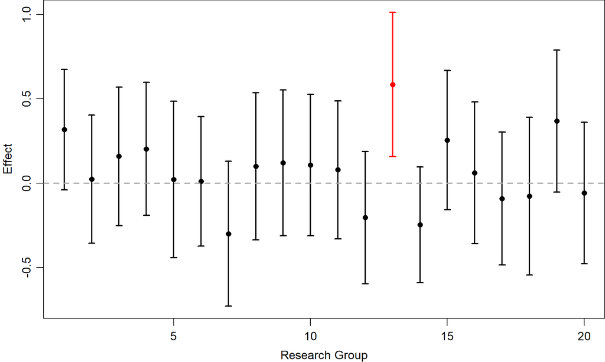

```r
set.seed(1)

# Given: mu = 0.1, sigma = 2, n = 100
nsim  <- 20
mu    <- 0.1
mu_0  <- 0
sigma <- 2
n     <- 100
SE    <- sigma/sqrt(n)
alpha <- .05

# Initialisation
dat <- data.frame(index = NA,
                  M     = NA,
                  sd    = NA,
                  se    = NA,
                  d_z   = NA,
                  p     = NA)[-1, ]

# Simulation
for (i in 1:nsim) {
  x   <- rnorm(n, mu, sigma)
  se  <- sd(x)/sqrt(n)
  d_z <- mean(x)/sd(x)
  p   <- t.test(x, mu = mu_0,
               alternative = "two.sided",
               conf.level = 1 - alpha)$p.value

  new_dat <- data.frame(index = i,
                        M     = mean(x),
                        sd    = sd(x),
                        se    = se,
                        d_z   = d_z,
                        p     = p)
  dat <- rbind(dat, new_dat)
}

# Plot
par(cex = 1.2, mar = c(3, 3, 0, 0), mgp = c(2, 0.7, 0))
ylim  <- c(min(dat$M - 2 * dat$se), max(dat$M + 2 * dat$se))
color <- ifelse(dat$p < alpha, "red", "black")
plot(M ~ index, dat, ylim = ylim, type = "n",
     ylab = "Effect", xlab = "Research Group")

# Mean values and confidence intervals
points(M ~ index, dat, pch = 16, col = color)
t_CI_q <- qt(1-alpha/2, n-1)
arrows(dat$index, dat$M - t_CI_q * dat$se,
       dat$index, dat$M + t_CI_q * dat$se,
       length = 0.05, angle = 90,
       code = 3, col = color, lwd = 2)

# Mark for critical value
abline(h = mu_0, col = "darkgrey", lty = 2, lwd = 2)
```

Die soliden Kreise in der Grafik stellen die erzielten Effekte in den 20 Experimenten dar, und die Fehlerbalken veranschaulichen das $95\%$-Konfidenzintervall. Die dunkelgraue Linie zeigt “Null-Effekt” an. Die rote Farbe wird für Experimente mit einem signifikanten Ergebnis im zweiseitigen $t$-Test verwendet und die schwarze für diejenigen mit einem nicht signifikanten Ergebnis.

Wie die Grafik zeigt, ist nur ein Experiment signifikant. Dies scheint intuitiv zu sein, da der wahre Effekt sehr klein ist. Wir können dies auch mit Hilfe von Power-Analyse erklären:

```r
power.t.test(n = n, delta = mu, sd = sigma,
             power = NULL, sig.level = alpha,
             alternative = 'two.sided', type = 'one.sample')
```

```
##
##      One-sample t test power calculation
##
##               n = 100
##           delta = 0.1
##              sd = 2
##       sig.level = 0.05
##           power = 0.07148842
##     alternative = two.sided
```

Da die Experimente nur eine geringe Teststärke haben, ist es sehr schwierig, einen vorhandenen Effekt nachzuweisen (obwohl er winzig ist, ist er existent).

Und was passiert bei dem einen Experiment, das signifikant ist?

```r
ex_dat <- dat[which.max(dat$M-dat$se), ]
ex_dat
```

```
##    index         M       sd        se       d_z
## 13    13 0.5851238 2.156673 0.2156673 0.2713086
##              p
## 13 0.007862687
```

Der beobachtete Effekt in diesem Experiment ist $\bar{x} \approx 0.59$ und der Cohen’s $d_z \approx 0.27$. Wenn man bedenkt, dass der wahre Effekt $\mu = 0.1$ und die wahre standardisierte Effektgröße $D_z = 0.05$ ist, stellt man fest, dass der beobachtete Effekt etwa 5-mal so groß ist wie der wahre.

Während es sehr schwierig ist, die Nullhypothese in einem Experiment mit geringer Teststärke zu verwerfen, liefert ein signifikantes Ergebnis eine deutliche Überschätzung des Effekts. Dies erklärt genau, warum das “$p$-Hacking” für die Wissenschaft schädlich ist, bei dem Forscher ein Experiment so lange wiederholen (bzw. die Stichprobengröße jedes Mal erhöhen), bis das Ergebnis signifikant ist, und nur dieses “glänzende” Ergebnis zeigen.

Um dies zu vermeiden, sollen die Forscher bewusst eine relevante Effektgröße festlegen und diese bei der Planung des Experiments verwenden. Insbesondere können sie mit Hilfe der Power-Analyse entscheiden, wie viele Teilnehmer sie erheben sollen, um ein signifikantes Ergebnis mit großer Teststärke zu erhalten.

### 4.4.1 Power-Analyse für die Versuchsplanung

Wenn man die Teststärke auf einen bestimmten Wert setzt, kann man mit den eingebauten R-Funktionen die Stichprobengröße berechnen, die für ein signifikantes Ergebnis erforderlich ist.

Für unser obiges Beispiel werden beispielsweise 3142 Teilnehmer benötigt, um eine Teststärke von $80\%$ zu erreichen.

```r
# Use raw effect
power.t.test(n = NULL, delta = 0.1, sd = 2, power = .8, sig.level = 0.05,
             alternative = 'two.sided', type = 'one.sample')
```

```
##
##      One-sample t test power calculation
##
##               n = 3141.473
##           delta = 0.1
##              sd = 2
##       sig.level = 0.05
##           power = 0.8
##     alternative = two.sided
```

```r
# Use standardised effect size
power.t.test(n = NULL, delta = 0.05, power = .8, sig.level = 0.05,
             alternative = 'two.sided', type = 'one.sample')
```

```
##
##      One-sample t test power calculation
##
##               n = 3141.473
##           delta = 0.05
##              sd = 1
##       sig.level = 0.05
##           power = 0.8
##     alternative = two.sided
```

## 4.5 Zusammenfassung

Der typische Hypothesentest nach Fisher betrachtet also nur die Abweichung von der Nullhypothese und schließt, falls die Abweichung groß genug ist, dass die Nullhypothese unplausibel ist und somit abgelehnt wird. Nichts weiter. Wenn die Nullhypothese nicht abgelehnt wird, heißt das nicht, dass wir sie bestätigt haben.

$$\begin{align*}
&\text{Wahrscheinlichkeit die Nullhypothese fälschlicherweise
abzulehnen: }&&\alpha
= P(\text{$H_0$ abgelehnt}|\text{$H_0$ wahr}) \\
&\text{Wahrscheinlichkeit die Nullhypothese fälschlicherweise
beizubehalten: }&&\beta
= P(\text{$H_0$ beibehalten}|\text{$H_0$ falsch})
\end{align*}$$

Die Wahrscheinlichkeit, die Nullhypothese korrekterweise abzulehnen wird oft als Teststärke bezeichnet, $1-\beta$.

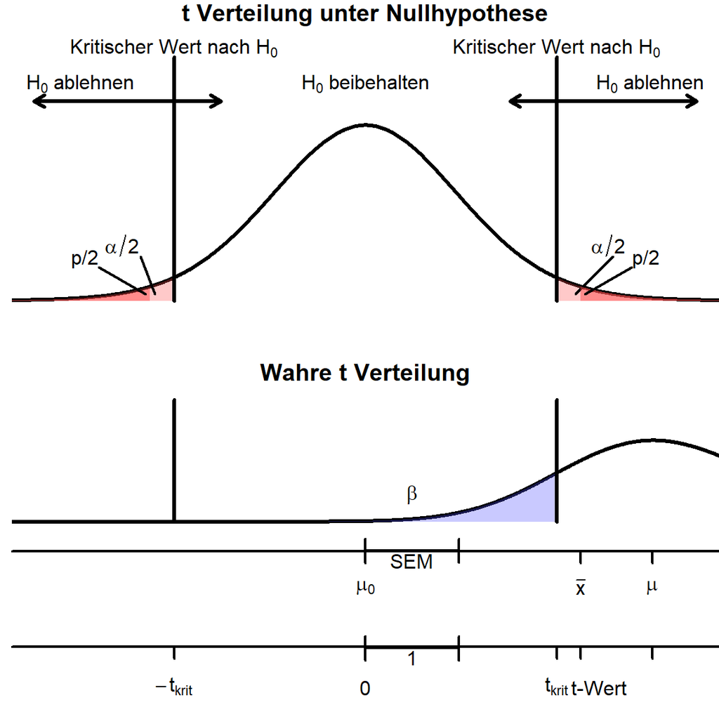

```r
# Random variable X: effect of a medication
X <- c(-2, -1, 0, 0, 0, 0, 1, 1, 1, 2, 3, 3, 3)
x <- as.numeric(unique(X))
f <- c(table(X)/length(X))
E <- sum( f %*% x )
VAR <- sum( f %*% (x - E)^2 )
SD <- sqrt(VAR)

# Stichprobe
N <- 30
SEM <- SD/sqrt(N)

## Two-part figure
par(mfrow = c(2, 1))
M <- 2.3

# First Figure (H0)
par(mar = c(2, 0.5, 1, 0))

# Distribution curves
x <- seq(-4, 4, .01)
f <- dt(x, df = N-1)
plot(x, f,
     type = 'l',
     xaxt = 'n', xlab = '', yaxt = 'n', ylab = '',
     frame.plot = F,
     xlim = c(-3.5, 3.5), ylim = c(0, .6), lwd = 3,
     main = 't Verteilung unter Nullhypothese')

# Alpha Area of Rejection
xcol <- seq(qt(.975, df = N-1), 5, .001)
fcol <- dt(xcol, df = N-1)
redCol <- rgb(1, .3, .3, .3)
polygon(c(xcol, rev(xcol)),
        c(fcol*0, rev(fcol)),
        col = redCol, border = NA)
text(2.6, .125, expression(alpha/2), xpd = T)
arrows(2.25, .015, 2.65, .1, code = 0, lwd = 2)

xcol <- seq(-5, qt(.025, df = N-1), .001)
fcol <- dt(xcol, df = N-1)
polygon(c(xcol, rev(xcol)),
        c(fcol*0, rev(fcol)),
        col = redCol, border = NA)
text(-2.6, .125, expression(alpha/2), xpd = T)
arrows(-2.25, .015, -2.4, .1, code = 0, lwd = 2)

# P Value
xcol <- seq(M, 5, .001)
fcol <- dt(xcol, df = N-1)
redCol <- rgb(1, .3, .3, .5)
polygon(c(xcol, rev(xcol)),
        c(fcol*0, rev(fcol)),
        col = redCol, border = NA, xpd = T)
text(3, .095, paste('p/2'), xpd = T,)
arrows(2.35, .015, 2.85, .075, code = 0, lwd = 2)

xcol <- seq(-5, -M, .001)
fcol <- dnorm(xcol)
polygon(c(xcol, rev(xcol)),
        c(fcol*0, rev(fcol)),
        col = redCol, border = NA)
text(-3, .095, paste('p/2'), xpd = T)
arrows(-2.35, .015, -2.85, .075, code = 0, lwd = 2)

# Borders
arrows(qt(.975, df = N-1), 0,
       qt(.975, df = N-1), 0.55,
       lwd = 3, code = 0)
text(qt(.975, df = N-1), .57,
     expression(paste('Kritischer Wert nach ',H[0])))

arrows(qt(.025, df = N-1), 0,
       qt(.025, df = N-1), 0.55,
       lwd = 3, code = 0)
text(qt(.025, df = N-1), .57,
     expression(paste('Kritischer Wert nach ',H[0])))

arrows(qt(.975, df = N-1), .45,
       qt(.975, df = N-1)+1.5, 0.45,
       lwd = 3, length = .1)
text(qt(.975, df = N-1)+1, .49,
     expression(paste(H[0],' ablehnen')))

arrows(qt(.025, df = N-1), .45,
       qt(.025, df = N-1)-1.5, 0.45,
       lwd = 3, length = .1)
text(qt(.025, df = N-1)-1, .49,
     expression(paste(H[0],' ablehnen')))

arrows(qt(.975, df = N-1), .45,
       qt(.975, df = N-1)-.5, 0.45,
       lwd = 3, length = .1)
arrows(qt(.025, df = N-1), .45,
       qt(.025, df = N-1)+.5, 0.45,
       lwd = 3, length = .1)
text(0, .49, expression(paste(H[0],' beibehalten')))


## Second plot (H1)
par(mar = c(8, 0.5, 1, 0))

# Distribution curves
x <- seq(-4, 4, .01)
f <- dt(x, df = N-1,
        ncp = E/SEM*sqrt((N-1)/2) * gamma((N-2)/2)/gamma((N-1)/2) )
plot(x, f,
     type = 'l', xaxt = 'n',
     xlab = '', yaxt = 'n', ylab = '', frame.plot = F,
     xlim = c(-3.5, 3.5), ylim = c(0, .6), lwd = 3,
     main = 'Wahre t Verteilung')

# Beta Area
xcol <- seq(qt(.025, df = N-1), qt(.975, df = N-1), .001)
gcol <- dt(xcol, df = N-1,
           ncp = E/SEM*sqrt((N-1)/2) * gamma((N-2)/2)/gamma((N-1)/2) )
blueCol <- rgb(.3,.3,1,.3)
polygon(c(xcol, rev(xcol)),
        c(gcol*0, rev(gcol)),
        col = blueCol, border = NA)
text(0.5, .125, expression(paste(beta)), xpd = T)


# Borders
arrows(qt(.975, df = N-1), 0,
       qt(.975, df = N-1), 0.55,
       lwd = 3, code = 0)

arrows(qt(.025, df = N-1), 0,
       qt(.025, df = N-1), 0.55,
       lwd = 3, code = 0)


# X Axis
axis(1, at = c(-1000, 0, M, E/SEM, 1000),
     labels = c(0, NA, NA, NA, 1),
     line = 1, lwd = 2)
axis(1, at = c(0, M, E/SEM),
     labels = c(expression(mu[0]), expression(bar(x)), expression(mu)),
     tick = F, line = 1)

arrows(0, -.13, 1, -.13, xpd = T, angle = 90, code = 3, length = .1, lwd = 2)
text(.5, -.175, 'SEM', xpd = T)

# T Axis
axis(1,
     at = c(-1000, qt(.025, df = N-1), 0, qt(.975, df = N-1), M, 1000, E/SEM),
     labels = c(NA, NA, NA, NA, NA, NA, NA),
     line = 5, lwd = 2)

axis(1,
     at = c(qt(.025, df = N-1), 0, qt(.975, df = N-1), M + 0.2, E/SEM+0.2),
     labels = c(expression(-t[krit]), 0, expression(t[krit]), 't-Wert', ''),
     tick = F, line = 5.2)

arrows(0, -.57, 1, -.57, xpd = T, angle = 90, code = 3, length = .1, lwd = 2)
text(.5, -.61, '1', xpd = T)
```

Konfidenzintervalle folgen der gleichen Logik. Auch hier ist es wichtig, auf die Interpretation zu achten: 95% der so konstruierten Konfidenzintervalle schließen den wahren Wert mit ein. Dagegen wehren sich Frequentisten gegen die Interpretation “zu 95% liegt der wahre Wert im Konfidenzintervall”, denn der wahre Wert ist festgelegt und liegt entweder darin oder nicht. Nur die erhobenen Daten sind variabel und wir treffen deshalb eine Wahrscheinlichkeitsaussage über das Konfidenzintervall und nicht über den wahren Wert. (Das wird dann später mit Bayesianischer Statistik gemacht.)

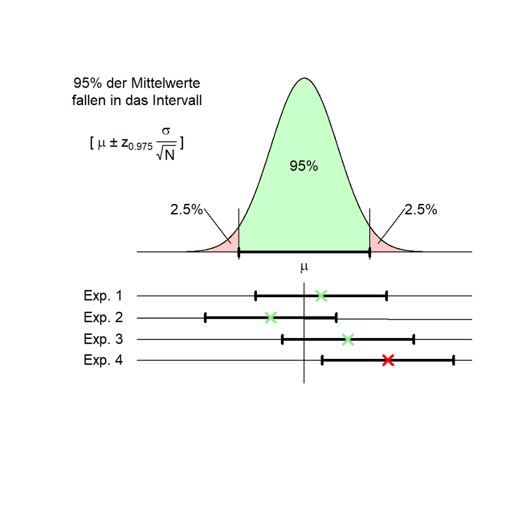

```r
x <- seq(-5, 5, .01)
f <- dnorm(x)

mar.default <- par('mar')
mar.new <- mar.default
mar.new[1] <- mar.new[1]+10
mar.new[2] <- mar.new[2]+3
par(mar = mar.new)

# Distribution
plot(x, f, type = 'l',
     xaxt='n', xlab = '',
     yaxt = 'n', ylab = '', frame.plot = F)

# Non-rejection area
arrows(0, -.07, 0, -.3, code = 0, xpd = T)
arrows(qnorm(.975), -.1, qnorm(.975), .1, code = 0)
arrows(qnorm(.025), -.1, qnorm(.025), .1, code = 0)
xcol <- seq(qnorm(.025), qnorm(.975), .001)
fcol <- dnorm(xcol)
greenCol <- rgb(.3, 1, .3, .3)
polygon(c(xcol, rev(xcol)),
        c(fcol*0, rev(fcol)),
        col = greenCol)

# Rejection area
xcol <- seq(-5, qnorm(.025), .001)
fcol <- dnorm(xcol)
redCol <- rgb(1, .3, .3, .3)
polygon(c(xcol, rev(xcol)),
        c(fcol*0, rev(fcol)),
        col = redCol)

xcol <- seq(qnorm(.975), 5, .001)
fcol <- dnorm(xcol)
redCol <- rgb(1, .3, .3, .3)
polygon(c(xcol, rev(xcol)),
        c(fcol*0, rev(fcol)),
        col = redCol)

# Marks of rejection areas
arrows(2.2, .02, 3, .1, code = 0)
text(3.5, .1, '2.5%')

arrows(-2.2, .02, -3, .1, code = 0)
text(-3.5, .1, '2.5%')

# Interpretation
text(0, .2, '95%')
text(-5, .35, '95% der Mittelwerte\nfallen in das Intervall\n', xpd = T)
text(-5, .25, bquote('['~mu~'\U00B1'~z[0.975]~frac(sigma,sqrt(N))~']'), xpd = T)

# Confidence interval
axis(1, at = c(0), labels = c(expression(mu)), lwd = 0, line = -1)
plotCI <- function(x, y)
{
  arrows(x+qnorm(.025), y,
         x+qnorm(.975), y,
         code = 0, lwd = 3, xpd = T)
  arrows(x+c(qnorm(.025), qnorm(.975)), y+c(-0.01, -0.01),
         x+c(qnorm(.025), qnorm(.975)), y+c(+0.01, +0.01),
         code = 0, lwd = 3, xpd = T)
}
plotCI(0, 0)

# Confidence interval of different experiments
text(-6, -0.1, 'Exp. 1', xpd = T)
arrows(-5, -0.1, 5, -0.1, code = 0, xpd = T)
plotCI(0.5, -0.1)
points(0.5, -0.1, xpd = T, pch = 4, cex = 1.5, lwd = 3, col = 'lightgreen')

text(-6, -0.15, 'Exp. 2', xpd = T)
arrows(-5, -0.15, 5, -0.155, code = 0, xpd = T)
plotCI(-1, -0.15)
points(-1, -0.15, xpd = T, pch = 4, cex = 1.5, lwd = 3, col = 'lightgreen')

text(-6, -0.2, 'Exp. 3', xpd = T)
arrows(-5, -0.2, 5, -0.2, code = 0, xpd = T)
plotCI(1.3, -0.2)
points(1.3, -0.2, xpd = T, pch = 4, cex = 1.5, lwd = 3, col = 'lightgreen')

text(-6, -0.2475, 'Exp. 4', xpd = T)
arrows(-5, -0.2475, 5, -0.2475, code = 0, xpd = T)
plotCI(2.5, -0.2475)
points(2.5, -0.2475, xpd = T, pch = 4, cex = 1.5, lwd = 3, col = 'red')
```

```r
par(mar = mar.default)
```

Aber es bleibt dabei, wenn ein hypothetisierter Wert außerhalb des Konfidenzintervalls liegt (und der beobachtete Mittelwert damit signifikant von diesem hypothetisierten Wert abweicht), geht man davon aus, dass dieser hypothetisierte Wert nicht der Wahrheit entspricht.

# 5 Visualisierungen

## 5.1 Barplot

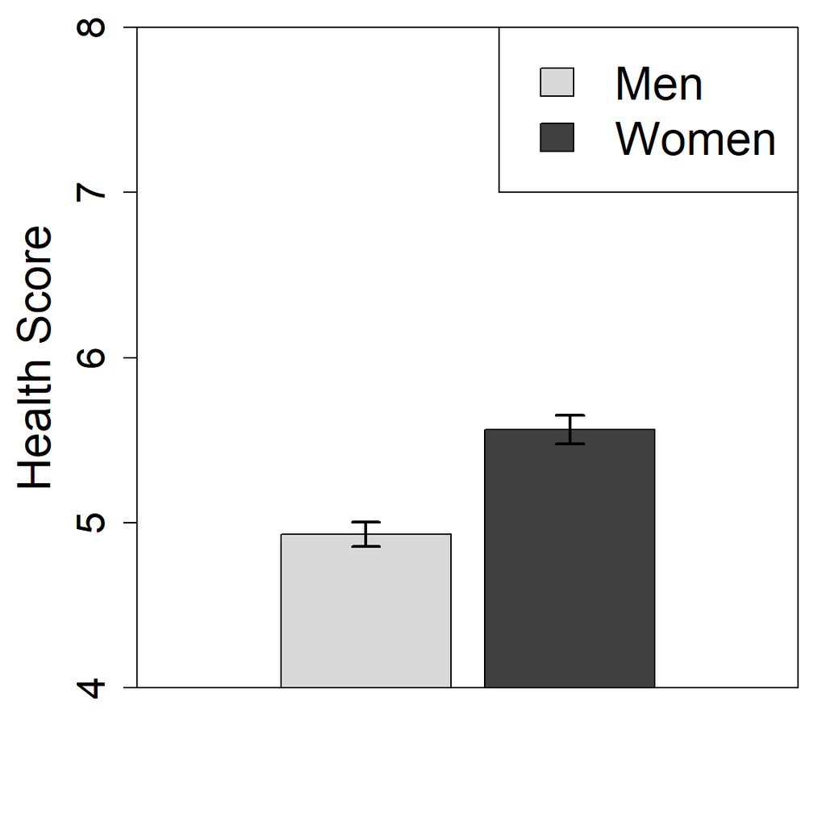

```r
# Load data
dat <- read.table("simulated_health_dat.csv")

# Effect of sex
sex_dat <- aggregate(data = dat,
                     health ~ part_id * sex_0,
                     mean)

x <- sex_dat$health[sex_dat$sex_0 == 0] # Men
y <- sex_dat$health[sex_dat$sex_0 == 1] # Women

sem <- function(x) { sd(x)/sqrt(length(x)) }

# Prepare data
Ms   <- c(mean(x), mean(y))
SEMs <- c(sem(x), sem(y))

# Barplot
par(mar = c(5, 5, 1, 1))
bx <- barplot(Ms,
              xlim     = c(-0.1, 0.62),
              ylim     = c(4, 8),
              xpd      = FALSE,
              width    = 0.2,
              col      = c("gray85", "gray25"),
              ylab     = "Health Score",
              cex.lab  = 2,
              cex.axis = 1.75)
box()

# Legend
legend("topright",
       fill   = c("gray85", "gray25"),
       legend = c("Men", "Women"),
       cex    = 2)

# Error bars
arrows(bx, Ms - SEMs,  # Lower position
       bx, Ms + SEMs,  # Upper position
       angle = 90,     # Orthogonal arrow heads
       code  = 3,      # Both sides
       len   = 0.1,    # Length of the bars
       lwd   = 2)      # Width of the lines
```

## 5.2 Histogramm

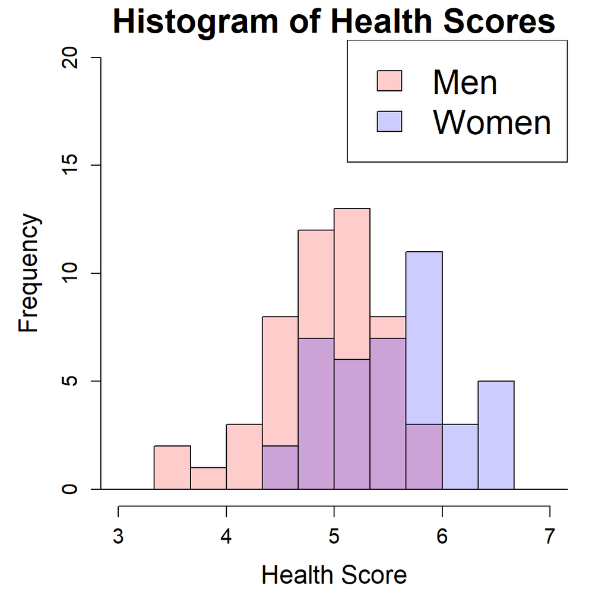

```r
# Load data
dat <- read.table("simulated_health_dat.csv")

# Effect of sex
sex_dat <- aggregate(data = dat,
                     health ~ part_id * sex_0,
                     mean)

x <- sex_dat$health[sex_dat$sex_0 == 0] # Men
y <- sex_dat$health[sex_dat$sex_0 == 1] # Women

sem <- function(x) { sd(x)/sqrt(length(x)) }

# Prepare data
Ms   <- c(mean(x), mean(y))
SEMs <- c(sem(x), sem(y))

# Histogram
par(mar = c(5, 5, 2, 2))
breaks <- seq(0, 10, 1/3)
hist(x,
     main     = "Histogram of Health Scores",
     xlab     = "Health Score",
     col      = rgb(1, 0, 0, .2),
     xlim     = c(3, 7),
     breaks   = breaks,
     cex.main = 2,
     cex.axis = 1.25,
     cex.lab  = 1.5,
     ylim     = c(0, 20))
hist(y,
     col = rgb(0, 0, 1, .2),
     breaks = breaks,
     add = TRUE)

# Legend
legend("topright",
       fill   = c(rgb(1, 0, 0, .2),
                  rgb(0, 0, 1, .2)),
       legend = c("Men", "Women"),
       cex    = 2)
```

## 5.3 Interaktionsplot

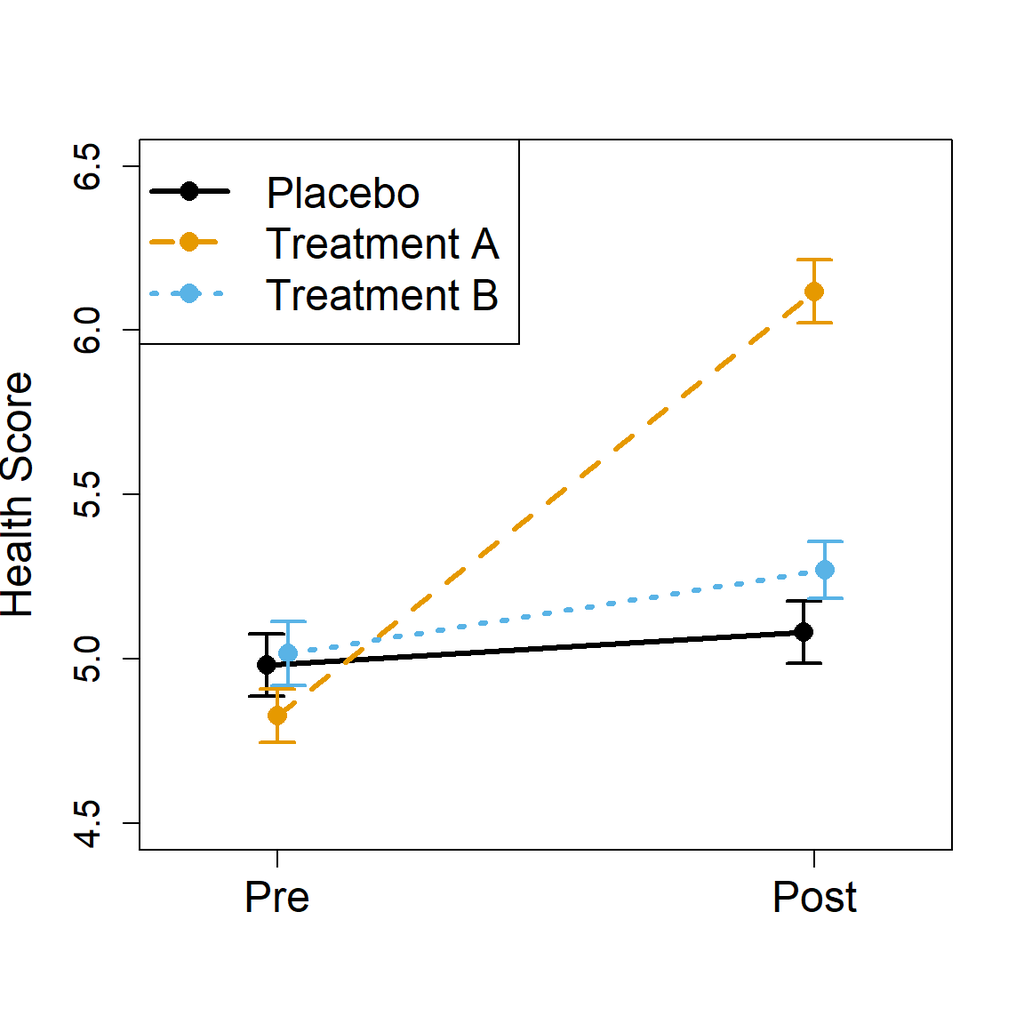

```r
# Load data
dat <- read.table("simulated_health_dat.csv")

# Effect of treatment
treatment_dat <- aggregate(data = dat,
                           health ~ part_id * treatment_a * treatment_b,
                           mean)

sem <- function(x) { sd(x)/sqrt(length(x)) }
mean_dat <- aggregate(data = dat,
                      health ~ placebo * treatment_a * treatment_b * pre * post,
                      function(x) { c(M   = mean(x),
                                      SEM = sem(x)) } )
mean_dat$health <- data.frame(mean_dat$health)

# Color Blind Palette (Okabe & Ito, 2008)
black          <- rgb(0, 0, 0)
orange         <- rgb(.9, .6, 0)
sky_blue       <- rgb(.35, .7, .9)
bluish_green   <- rgb(0, .6, .5)
yellow         <- rgb(.95, .9, .25)
blue           <- rgb(0, .45, .7)
vermillon      <- rgb(.8, .4, 0)
reddish_purple <- rgb(.8, .6, .7)

# Interaction plot
x_jitter <- seq(-0.02, +0.02, length.out = 3)
plot(mean_dat$post + x_jitter,
     mean_dat$health$M,
     pch      = 16,
     cex      = 1.5,
     col      = c(black, orange, sky_blue),
     xlim     = c(-0.2, 1.2),
     ylim     = c(4.5, 6.5),
     xaxt     = "n",
     xlab     = "",
     ylab     = "Health Score",
     cex.lab  = 1.5,
     cex.axis = 1.25)
axis(1, at = c(0, 1),
     labels = c("Pre", "Post"),
     cex.axis = 1.5)

# Lines between points
arrows(mean_dat$post[mean_dat$post == 0] + x_jitter,
       mean_dat$health$M[mean_dat$post == 0],
       mean_dat$post[mean_dat$post == 1] + x_jitter,
       mean_dat$health$M[mean_dat$post == 1],
       code = 0,
       col  = c(black, orange, sky_blue),
       lwd  = 3,
       lty  = 1:3)

# Error bars
arrows(mean_dat$post + x_jitter,
       mean_dat$health$M - mean_dat$health$SEM,
       mean_dat$post + x_jitter,
       mean_dat$health$M + mean_dat$health$SEM,
       code  = 3,
       angle = 90,
       col   = c(black, orange, sky_blue),
       lwd   = 2,
       len   = 0.1)

# Legend
legend("topleft",
       legend = c("Placebo",
                  "Treatment A",
                  "Treatment B"),
       col    = c(black, orange, sky_blue),
       lty    = 1:3,
       pch    = 16,
       cex    = 1.5,
       lwd    = 3)
```

# 6 ANOVA

Eine Varianzanalyse (Analysis of Variances, ANOVA) betrachtet, ob die Abweichungen der Beobachtungen von der Nullhypothese durch die Varianz der Beobachtungen erklärt werden können oder ob es systematische Abweichungen gibt. Es ist also eine Verallgemeinerung von den $t$-Tests, die wir kennengelernt haben.

Betrachten wir zum Anfang wieder kurz einen Würfel und nehmen als Beispiel an, dass es drei Varianten gibt, den Würfel zu werfen: (a) normal werfen, (b) die Sechs nach oben legen und dann werfen, (c) die Eins nach oben legen und dann werfen. Nun werfen wir in jeder Bedingung den Würfel $N = 30$ Mal und notieren die Mittelwerte.

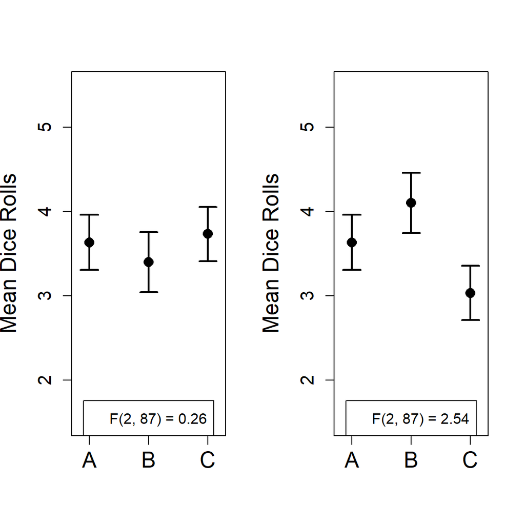

```r
set.seed(2024-01-04)
x_A <- sample(1:6, 30, replace = TRUE)
x_B <- sample(1:6, 30, replace = TRUE)
x_C <- sample(1:6, 30, replace = TRUE)

# Means
m_A <- mean(x_A)
m_B <- mean(x_B)
m_C <- mean(x_C)
Ms  <- c(m_A, m_B, m_C)

# SEMs
sem_A <- sem(x_A)
sem_B <- sem(x_B)
sem_C <- sem(x_C)
SEMs  <- c(sem_A, sem_B, sem_C)

par(mfrow = c(1, 2))

# Mean plot
plot(1:3,
     Ms,
     pch      = 16,
     cex      = 1.5,
     xlim     = c(0.8, 3.2),
     ylim     = c(1.5, 5.5),
     xaxt     = "n",
     xlab     = "",
     ylab     = "Mean Dice Rolls",
     cex.lab  = 1.5,
     cex.axis = 1.25)
axis(1, at = c(1, 2, 3), labels = c("A", "B", "C"),
     cex.axis = 1.5)

# Error bars
arrows(1:3,
       Ms - SEMs,
       1:3,
       Ms + SEMs,
       code  = 3,
       angle = 90,
       lwd   = 2,
       len   = 0.1)

dat <- data.frame(i = factor(rep(1:3, each = 30)),
                  x = c(x_A, x_B, x_C))
anova_evaluation <- anova(lm(x~i, data = dat))
F_value <- unlist(anova_evaluation)[7]
legend("bottom", paste0("F(2, 87) = ", round(F_value, 2)))

# Mean plot
Ms <- Ms + c(0, +0.7, -0.7)
plot(1:3,
     Ms,
     pch      = 16,
     cex      = 1.5,
     xlim     = c(0.8, 3.2),
     ylim     = c(1.5, 5.5),
     xaxt     = "n",
     xlab     = "",
     ylab     = "Mean Dice Rolls",
     cex.lab  = 1.5,
     cex.axis = 1.25)
axis(1, at = c(1, 2, 3), labels = c("A", "B", "C"),
     cex.axis = 1.5)

# Error bars
arrows(1:3,
       Ms - SEMs,
       1:3,
       Ms + SEMs,
       code  = 3,
       angle = 90,
       lwd   = 2,
       len   = 0.1)

# Legend
dat <- data.frame(i = factor(rep(1:3, each = 30)),
                  x = c(x_A, x_B+0.7, x_C-0.7))
anova_evaluation <- anova(lm(x~i, data = dat))
F_value <- unlist(anova_evaluation)[7]
legend("bottom", paste0("F(2, 87) = ", round(F_value, 2)))
```

```r
par(mfrow = c(1, 1))
```

Bei der ANOVA wird davon ausgegangen, dass die einzelnen Beobachtungen normalverteilt sind und dass die Varianz in jeder Gruppe gleich ist (anders als beim $t$-Test).

$$X_{ij} = \mu_i + \varepsilon_{ij} \text{ mit } \varepsilon_{ij}
\sim \mathcal{N}(0, \sigma^2)$$

Als Nullhypothese verwenden wir, dass die Erwartungswerte aller Gruppen gleich sind.

$$\text{Nullhypothese: } \mu_1 = \mu_2 = ... = \mu_I$$

Da wird jetzt potenziell mehr als zwei Mittelwerte (jeweils einer pro Gruppe) haben, quantifizieren wir die Abweichung nicht mehr als $t = \frac{\bar{X} - \mu_0}{SEM}$ sondern als

$$F = \frac{
\frac{ \sum_{i=1}^{I} \sum_{j = 1}^{N} (\hat{X}_{ij} -
\bar{X})^2 }{ I - 1 }
}{
\frac{ \sum_{i=1}^{I} \sum_{j = 1}^{N} (X_{ij} -
\hat{X}_{ij})^2 }{ N - I }
}
= \frac{\frac{\text{SQE}}{df_E}}{\frac{\text{SQR}}{df_R}}
= \frac{\text{MQE}}{\text{MQR}}$$

mit $\hat{X}_{ij}$ als Gruppenmittelwert, $\bar{X}$ Gesamtmittelwert und $X_{ij}$ Einzelbeobachtung.

Falls die Nullhypothese wahr ist, kann hergeleitet werden, wie die $F$-Werte verteilt sind. Die Herleitung überspringen wir hier, aber als Ergebnis erhalten wir, dass sie der $F$-Verteilung folgen, die von $N$ und $I$ abhängt und deren Quantile in R mit `qf` berechnet werden können. Dadurch können wir den $p$-Wert berechnen, also die Wahrscheinlichkeit den beobachteten $F$-Wert oder einen noch größeren zu erhalten, falls die Nullhypothese stimmt. Wie zuvor lehnen wir die Nullhypothese bei kleinen $p$-Werten ab.

[figure not shown]

```r
# Distribution curve
fs <- seq(0, 6, .01)
ff <- df(fs, 2, 87)
plot(fs, ff,
     type     = "l",
     xlab     = "F value",
     ylab     = "Density",
     cex.lab  = 1.5,
     cex.axis = 1.25)

# Mark of an F value
F_value <- 2.54
axis(1, at = F_value, label = F_value, cex = 1.25)

# Visualize p value
xcol <- seq(F_value, 6, .01)
fcol <- df(xcol, 2, 87)
redCol <- rgb(1, .3, .3, .3)
polygon(c(xcol, rev(xcol)),
        c(fcol*0, rev(fcol)),
        col = redCol, border = NA)
text(3.3, .125, "p = .073", xpd = T, cex = 1.5)
```

## 6.1 Einfaktorielle ANOVA (Gruppen)

```r
set.seed(2024-01-04)

# Simulated data
N   <- 30
x_A <- rnorm(N, mean = +1.2, sd = 2)
x_B <- rnorm(N, mean = +1.8, sd = 2)
x_C <- rnorm(N, mean = +0.5, sd = 2)

dat <- data.frame(manufacturer = factor(rep(1:3, each = 30)),
                  health       = c(x_A, x_B, x_C))

# ANOVA
model <- lm(health ~ manufacturer, data = dat)
# cor(predict(model), dat$health)^2 # 0.06
anova(model)
```

```
## Analysis of Variance Table
##
## Response: health
##              Df  Sum Sq Mean Sq F value  Pr(>F)
## manufacturer  2  18.803  9.4015  2.6233 0.07829 .
## Residuals    87 311.791  3.5838
## ---
## Signif. codes:
## 0 '***' 0.001 '**' 0.01 '*' 0.05 '.' 0.1 ' ' 1
```

> We found no evidence that health depends on the manufacturer of the prescribed medication, $F(2, 87) = 2.6$, $p = .078$, $R^2 = .06$.

Wir erwähnen hier den quadrierten Korrelationskoeffizienten, den sogenannten Determinationskoeffizienten, als Maß für die Effektgröße: Er bestimmt den prozentualen Anteil der Varianz, der durch die unabhängige Variable aufgeklärt wird.

$$R^2 = \frac{\text{SQE}}{\text{SQT}} =
\frac{\text{SQE}}{\text{SQR + SQE}}$$

## 6.2 Lineare Regression

Lineare Regression wird auch über eine ANOVA analysiert, nur dass die Vorhersagen jetzt nicht über Gruppenmittelwerte sondern über eine Gerade gemacht werden. Im vorherigen Beispiel hatten wir drei Gruppen, die in keiner Reihenfolge zueinander stehen, also nicht einmal ordinalskaliert sind. Von einer linearen Regression spricht man dagegen, wenn die unabhängige Variable metrisch ist.

Es gibt hierbei abhängige Beobachtungen wie die Gesundheitswerte, die wir jetzt $Y_1$, …, $Y_N$ nennen. Daneben gibt es unabhängige Beobachtungen $X_1$, …, $X_N$, mit denen wir die abhängigen Beobachtungen vorhersagen wollen. Wir nehmen als Beispiel, dass wir die Gesundheitswerte $Y$ durch das Alter $X$ vorhersagen wollen. Die Grundannahme ist, dass es einen linearen Zusammenhang gibt:

$$Y_i = \alpha + \beta \cdot X_i + \epsilon_i
\text{ mit } \epsilon_i \sim \mathcal{N}(0, \sigma^2)$$

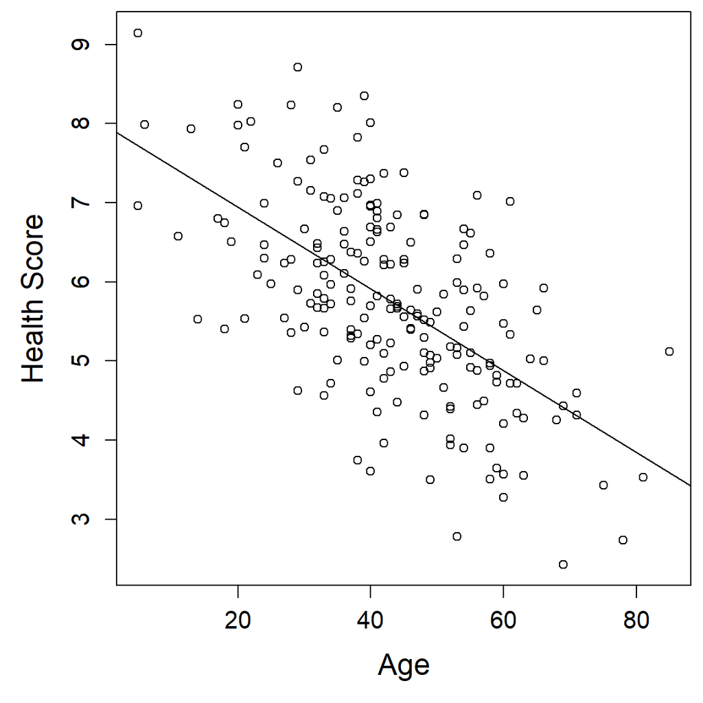

```r
set.seed(2024-01-04)

# Simulate data
alpha  <- 8
beta   <- -0.05

N      <- 200
age    <- round(rnorm(N, mean = 45, sd = 15))
noise  <- rnorm(N, mean = 0, sd = 1)
health <- alpha + beta * age + noise

dat <- data.frame(i      = 1:N   ,
                  age    = age   ,
                  health = health)

# Plot
par(mar = c(5, 5, 0.5, 0.5))
plot(age, health,
     xlab     = "Age",
     ylab     = "Health Score",
     cex.axis = 1.25,
     cex.lab  = 1.5)

# Regression line
model <- lm(health ~ age, data = dat)
# cor(dat$age, dat$health)^2 # 0.36
abline(model)
```

```r
# ANOVA
anova(model)
```

```
## Analysis of Variance Table
##
## Response: health
##            Df Sum Sq Mean Sq F value    Pr(>F)
## age         1 107.76 107.760     112 < 2.2e-16 ***
## Residuals 198 190.50   0.962
## ---
## Signif. codes:
## 0 '***' 0.001 '**' 0.01 '*' 0.05 '.' 0.1 ' ' 1
```

> We found a statistical effect of age on health, $F(1, 198) = 112$, $p < .001$, $R^2 = .36$.

- Es könnte sein, dass Alter zu geringerer Gesundheit führt, was in diesem Beispiel sehr plausibel ist, aber eben noch nicht nachgewiesen.
- Es kann aber auch sein, dass Menschen mit einer schlechten Gesundheit älter werden (z.B. weil sie weniger rausgehen und dadurch seltener durch Unfälle sterben).
- Es kann auch sein, dass ein dritter Faktor beide Aspekte bestimmt (z.B. könnten bestimmte Gene krankheitsanfällig machen aber gleichzeitig mit langer Lebenserwartung einhergehen).

Um eine Kausation zu belegen, ist zufälliges Bestimmen (Randomisieren) der unabhängigen Variable notwendig: Wenn dann weiterhin ein statistischer Effekt vorliegt, ist eine Kausation der unabhängigen Variable auf die abhängige Variable gegeben.

Die Parameter in einer Regression können wir aber auch mit $t$-Tests testen.

```r
summary(model)
```

```
##
## Call:
## lm(formula = health ~ age, data = dat)
##
## Residuals:
##      Min       1Q   Median       3Q      Max
## -2.46194 -0.65998 -0.05275  0.76832  2.38421
##
## Coefficients:
##              Estimate Std. Error t value Pr(>|t|)
## (Intercept)  7.984179   0.222025   35.96   <2e-16 ***
## age         -0.051705   0.004886  -10.58   <2e-16 ***
## ---
## Signif. codes:
## 0 '***' 0.001 '**' 0.01 '*' 0.05 '.' 0.1 ' ' 1
##
## Residual standard error: 0.9809 on 198 degrees of freedom
## Multiple R-squared:  0.3613, Adjusted R-squared:  0.3581
## F-statistic:   112 on 1 and 198 DF,  p-value: < 2.2e-16
```

## 6.3 Logistische Regression

Statt der linearen Funktion $Y_i = \alpha + \beta \cdot X_i + \epsilon_i$ können wir auch nichtlineare Funktionen schätzen. Dabei verwenden wir eine nichtlineare Funktion $g^{-1}$, die den nichtlinearen Zusammenhang ausdrückt: $Y_i = g^{-1}(\alpha + \beta \cdot X_i) + \epsilon_i$. Diese Modelle nennen wir generalisierte, lineare Modelle (generalized linear models, GLM).

Wir betrachten ein konkretes Beispiel bei dem $g^{-1}(\alpha + \beta \cdot X_i) = \frac{1}{1 + e^{-(\alpha + \beta \cdot X_i)}}$ — diese Funktion heißt logistische Funktion. Diese Funktion sagt Wahrscheinlichkeiten vorher: Für jedes $X_i$ ist $p_i = g^{-1}(\alpha + \beta \cdot X_i)$ die vorhergesagte Wahrscheinlichkeit, dass $Y_i = 1$. Die Parameter, oder Koeffizienten, $\alpha$ und $\beta$ werden so geschätzt, dass die Likelihood für die Daten maximal ist: $\mathcal{L} = \prod\limits_{i,\,Y_i = 1} p_i \cdot \prod\limits_{i,\,Y_i = 0} (1 - p_i)$. (Dafür gibt es spezielle Algorithmen, die die optimalen Werte finden, auf die wir hier nicht eingehen.) Nehmen wir zum Beispiel an, dass $X_i$ das Alter von verschiedenen Patienten ist und $Y_i$ gibt an, ob der Patient ein Medikament verschrieben bekommen hat ($Y_i = 1$) oder nicht ($Y_i = 0$).

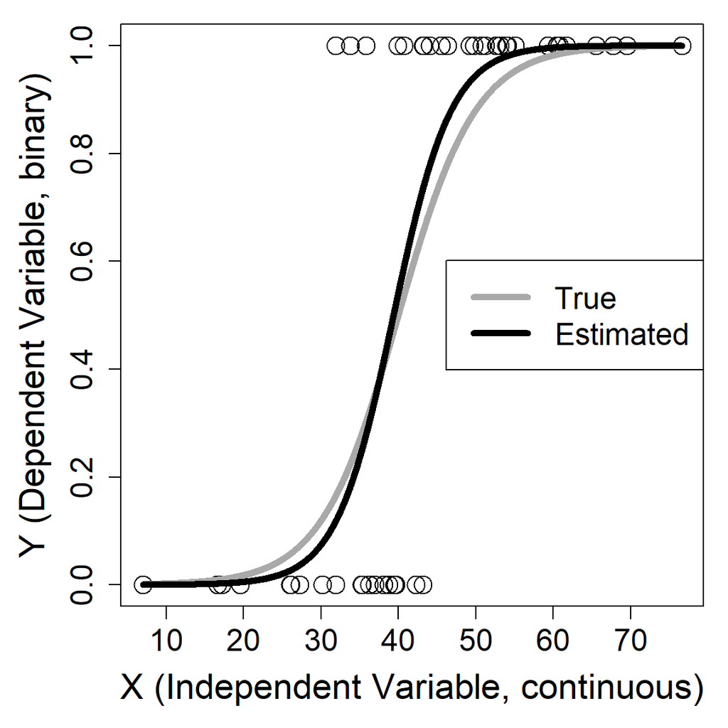

```r
set.seed(2024-01-13)

# Underlying parameters
logistic <- function(x, alpha, beta) { 1/(1 + exp(-(alpha + beta * x))) }

# Simulate data
n <- 50
x <- rnorm(n, mean = 40, sd = 15)
y <- rbinom(n, 1, logistic(x, alpha = -8, beta = 0.2))
dat <- data.frame(x = x,
                  y = y)

# Estimate logistic regression
model <- glm(data = dat,
             y ~ x,
             family = "binomial")
estimated_alpha <- model$coefficients[1]
estimated_beta  <- model$coefficients[2]

# Visualize
par(mar = c(5, 5, 1, 1))
plot(dat$x, dat$y,
     xlab = "X (Independent Variable, continuous)",
     ylab = "Y (Dependent Variable, binary)",
     cex.lab  = 1.75,
     cex.axis = 1.5,
     cex      = 2)
xs <- seq(min(dat$x), max(dat$x), .01)

# Logistic Function curves
points(xs, logistic(xs, alpha = -8, beta = 0.2),
       type = "l", lwd = 5, col = "darkgray")
points(xs, logistic(xs, estimated_alpha, estimated_beta),
       type = "l", lwd = 5)

# Legend
legend("right",
       lty = c(1, 1),
       lwd = c(5, 5),
       col = c("darkgray", "black"),
       legend  = c("True", "Estimated"),
       cex = 1.5)
```

Die Modell Parameter werden wie bei der Regression wieder getestet wie bei einem $t$ Test. Exakterweise, wird dieser Test Wald-Test genannt und man schreibt $z$-Werte, weil die approximative Normalverteilung (statt der $t$-Verteilung) verwendet wird.

```r
# Output model estimates
summary(model)
```

```
##
## Call:
## glm(formula = y ~ x, family = "binomial", data = dat)
##
## Coefficients:
##              Estimate Std. Error z value Pr(>|z|)
## (Intercept) -10.57284    3.34816  -3.158  0.00159 **
## x             0.26842    0.08299   3.234  0.00122 **
## ---
## Signif. codes:
## 0 '***' 0.001 '**' 0.01 '*' 0.05 '.' 0.1 ' ' 1
##
## (Dispersion parameter for binomial family taken to be 1)
##
##     Null deviance: 66.406  on 49  degrees of freedom
## Residual deviance: 29.248  on 48  degrees of freedom
## AIC: 33.248
##
## Number of Fisher Scoring iterations: 7
```

> In a logistic regression model, we found that age increases the risk of being prescripted medication ($b = 0.27$, $SE = 0.08$, $p = .001$).

## 6.4 Mehrfaktorielle ANOVA

Meistens werden ANOVAs durchgeführt, wenn mehrere Faktoren (unabhängige Variablen) zugleich eine abhängige Variable beeinflussen. Dadurch lassen sich dann Interaktionseffekte beschreiben, also dass es auf die konkrete Kombination von unabhängigen Variablen ankommt. Die Grundannahmen bleiben wie zuvor. Hier ein Beispiel, in dem Geschlecht und Medikation einen Interaktionseffekt zeigen.

```r
set.seed(2024-01-04)

# Simulate data
alpha <- 5
beta_med_women <-  0
beta_med_men   <- +1

N          <- 200
sex        <- c(rep(0, N/2), rep(1, N/2))
medication <- rep(c(0, 1), N/2)
noise      <- rnorm(N, mean = 0, sd = 1)
health[sex == 0] <- alpha + beta_med_women * medication[sex == 0] + noise[sex == 0]
health[sex == 1] <- alpha + beta_med_men   * medication[sex == 1] + noise[sex == 1]

dat <- data.frame(i          = 1:N               ,
                  sex        = factor(sex       ),
                  medication = factor(medication),
                  health     = health            )

# ANOVA
model <- lm(health ~ sex * medication, data = dat)
anova(model)
```

```
## Analysis of Variance Table
##
## Response: health
##                 Df  Sum Sq Mean Sq F value    Pr(>F)
## sex              1   8.125  8.1251  8.9795  0.003083
## medication       1  15.861 15.8607 17.5285 4.273e-05
## sex:medication   1   8.280  8.2800  9.1507  0.002819
## Residuals      196 177.350  0.9048
##
## sex            **
## medication     ***
## sex:medication **
## Residuals
## ---
## Signif. codes:
## 0 '***' 0.001 '**' 0.01 '*' 0.05 '.' 0.1 ' ' 1
```

```r
model1 <- lm(health ~ sex, data = dat)
model2 <- lm(health ~ sex + medication, data = dat)
model3 <- lm(health ~ sex * medication, data = dat)
R2_1 <- cor(predict(model1), dat$health)^2
R2_2 <- cor(predict(model2), dat$health)^2
R2_3 <- cor(predict(model3), dat$health)^2
# R2_1        # .04
# R2_2 - R2_1 # .08
# R2_3 - R2_2 # .04
```

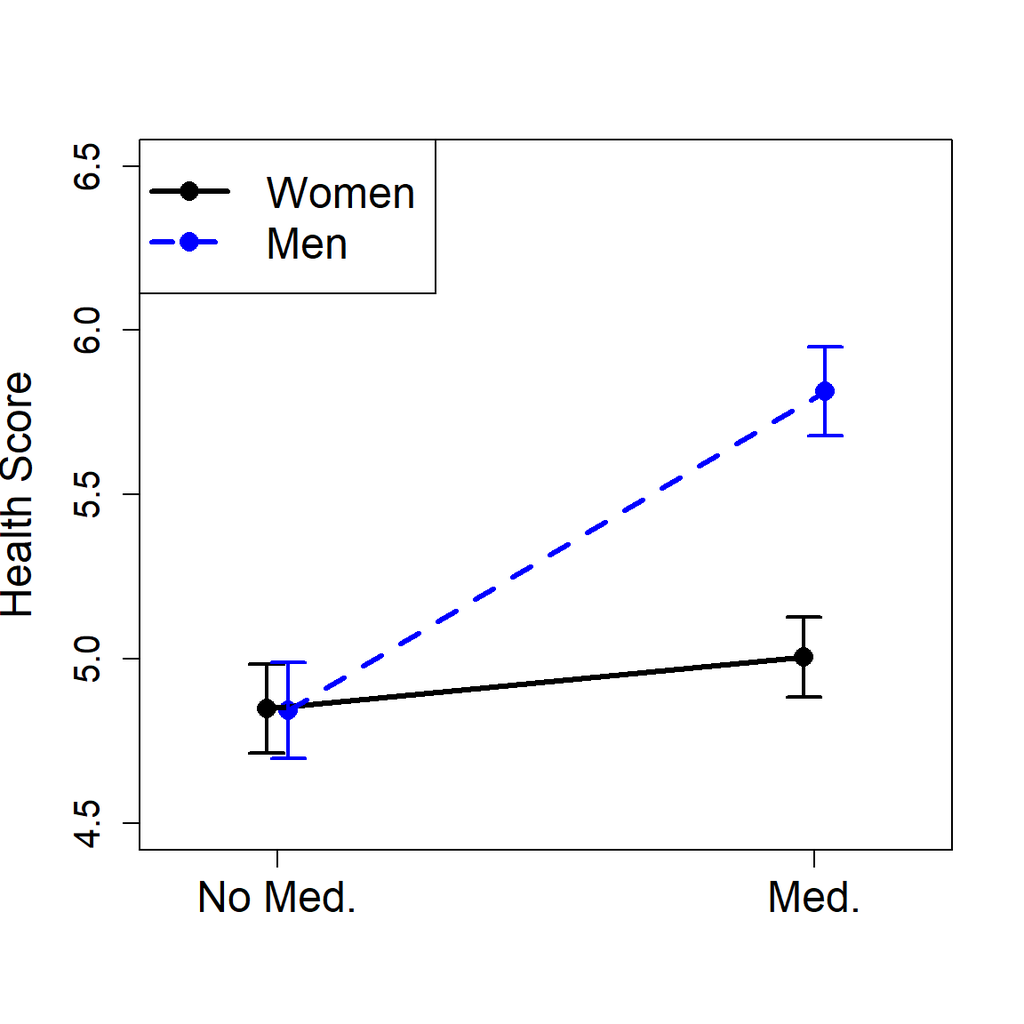

```r
# Effect of treatment
sem <- function(x) { sd(x)/sqrt(length(x)) }
mean_dat <- aggregate(data = dat,
                      health ~ sex * medication,
                      function(x) { c(M   = mean(x),
                                      SEM = sem(x)) } )
mean_dat$health <- data.frame(mean_dat$health)

# Interaction plot
x_jitter <- seq(-0.02, +0.02, length.out = 2)
plot(as.numeric(mean_dat$medication) + x_jitter,
     mean_dat$health$M,
     pch      = 16,
     cex      = 1.5,
     xlim     = c(0.8, 2.2),
     ylim     = c(4.5, 6.5),
     xaxt     = "n",
     xlab     = "",
     ylab     = "Health Score",
     cex.lab  = 1.5,
     cex.axis = 1.25,
     col = c("black", "blue"))
axis(1, at = c(1, 2), labels = c("No Med.", "Med."),
     cex.axis = 1.5)

# Lines between points
arrows(as.numeric(mean_dat$medication[mean_dat$medication == 0]) + x_jitter,
       mean_dat$health$M[mean_dat$medication == 0],
       as.numeric(mean_dat$medication[mean_dat$medication == 1]) + x_jitter,
       mean_dat$health$M[mean_dat$medication == 1],
       code = 0,
       lwd  = 3,
       lty  = 1:2,
       col = c("black", "blue"))

# Error bars
arrows(as.numeric(mean_dat$medication) + x_jitter,
       mean_dat$health$M - mean_dat$health$SEM,
       as.numeric(mean_dat$medication) + x_jitter,
       mean_dat$health$M + mean_dat$health$SEM,
       code  = 3,
       angle = 90,
       lwd   = 2,
       len   = 0.1,
       col = c("black", "blue"))

# Legend
legend("topleft",
       legend = c("Women", "Men"),
       lty    = 1:2,
       pch    = 16,
       cex    = 1.5,
       lwd    = 3,
       col = c("black", "blue"))
```

Achtung bei Analysen von Datensätzen, in denen die unabhängigen Variablen konfundiert sind (zusammenhängen). Bei der Interpretation ist wichtig zu berücksichtigen, dass die Effekte der Reihe nach, sequenziell, evaluiert werden.

```r
## Simulate data
set.seed(2)
n          <- 60
Sex        <- rbinom(n, 1, .5)
Occupation <- rbinom(n, 1, .3 + .4*Sex)
Salary     <- 2000 + 500*Occupation + rnorm(length(Occupation), sd = 100)

## Inspect data
T1 <- table(Sex, Occupation)
Ms <- aggregate(list(Salary = Salary),
                by = list(Sex = Sex, Occupation = Occupation),
                mean)$Salary
T2 <- T1
T2[1, 1] <- Ms[1]; T2[2, 1] <- Ms[2]; T2[1, 2] <- Ms[3]; T2[2, 2] <- Ms[4];
T1; T2
```

```
##    Occupation
## Sex  0  1
##   0 19  9
##   1  8 24
```

```
##    Occupation
## Sex        0        1
##   0 1977.648 2511.138
##   1 2049.711 2488.737
```

```r
dat <- data.frame(Y = Salary, A = Sex, B = Occupation)


## Different sequential summed squares results
summary(aov(lm(Salary ~ Sex)))
```

```
##             Df  Sum Sq Mean Sq F value   Pr(>F)
## Sex          1  788967  788967   12.75 0.000724 ***
## Residuals   58 3589600   61890
## ---
## Signif. codes:
## 0 '***' 0.001 '**' 0.01 '*' 0.05 '.' 0.1 ' ' 1
```

```r
summary(aov(lm(Salary ~ Occupation)))
```

```
##             Df  Sum Sq Mean Sq F value Pr(>F)
## Occupation   1 3651073 3651073   291.1 <2e-16 ***
## Residuals   58  727494   12543
## ---
## Signif. codes:
## 0 '***' 0.001 '**' 0.01 '*' 0.05 '.' 0.1 ' ' 1
```

```r
summary(aov(lm(Salary ~ Sex * Occupation)))
```

```
##                Df  Sum Sq Mean Sq F value   Pr(>F)
## Sex             1  788967  788967  63.574 8.55e-11 ***
## Occupation      1 2867618 2867618 231.068  < 2e-16 ***
## Sex:Occupation  1   27007   27007   2.176    0.146
## Residuals      56  694975   12410
## ---
## Signif. codes:
## 0 '***' 0.001 '**' 0.01 '*' 0.05 '.' 0.1 ' ' 1
```

```r
summary(aov(lm(Salary ~ Occupation * Sex)))
```

```
##                Df  Sum Sq Mean Sq F value Pr(>F)
## Occupation      1 3651073 3651073 294.198 <2e-16 ***
## Sex             1    5512    5512   0.444  0.508
## Occupation:Sex  1   27007   27007   2.176  0.146
## Residuals      56  694975   12410
## ---
## Signif. codes:
## 0 '***' 0.001 '**' 0.01 '*' 0.05 '.' 0.1 ' ' 1
```

## 6.5 Messwiederholungs ANOVA (Repeated Measures ANOVA)

Häufig gibt es Versuchsdesigns, bei denen die gleichen Versuchspersonen in mehreren Gruppen Beobachtungen liefern. Es werden also wiederholt Messungen an den gleichen Versuchspersonen durchgeführt. Dann brauchen wir eine ANOVA mit Messwiederholungen, bei denen die individuellen Effekte rausgerechnet werden. Zum Beispiel wird bei einem Reaktionszeitexperiment rausgerechnet, dass manche Personen in allen Experimentbedingungen langsam sind und andere immer schnell. Das erlaubt die Effekte, die auf die Bedingungen zurück gehen, klarer herauszustellen.

```r
set.seed(2024-01-04)

# Simulated data
N   <- 30
x_A <- rnorm(N, mean = +1.2, sd = 2)
x_B <- rnorm(N, mean = +1.8, sd = 2)
x_C <- rnorm(N, mean = +0.4, sd = 2)

# Variability between participants
sportiness <- rnorm(N, mean = 0, sd = 2)
x_A <- x_A + sportiness
x_B <- x_B + sportiness
x_C <- x_C + sportiness

dat <- data.frame(i            = factor(rep(1:N, 3)),
                  manufacturer = factor(rep(1:3, each = 30)),
                  health       = c(x_A, x_B, x_C))

# ANOVA
model <- lm(health ~ manufacturer, data = dat)
# cor(predict(model), dat$health)^2 # 0.03
anova(model)
```

```
## Analysis of Variance Table
##
## Response: health
##              Df Sum Sq Mean Sq F value Pr(>F)
## manufacturer  2  21.85 10.9238  1.6056 0.2067
## Residuals    87 591.92  6.8037
```

```r
# install.packages("ez")
library(ez)
print(ezANOVA(data = dat,
              dv = health,
              within = manufacturer,
              wid = i))
```

```
## $ANOVA
##         Effect DFn DFd        F          p p<.05
## 2 manufacturer   2  58 3.248326 0.04600805     *
##          ges
## 2 0.03559605
##
## $`Mauchly's Test for Sphericity`
##         Effect         W         p p<.05
## 2 manufacturer 0.9098155 0.2662849
##
## $`Sphericity Corrections`
##         Effect       GGe      p[GG] p[GG]<.05
## 2 manufacturer 0.9172759 0.05069572
##         HFe      p[HF] p[HF]<.05
## 2 0.9761767 0.04731179         *
```

> In a repeated measures ANOVA, we found that the health of participants taking prescribed medication depended on the manufacturer, $F(2, 58) = 3.25$, $p = .046$. (There was no violation of sphericity and this effect remained significant after correcting for the marginal deviations from sphericity, $p = .047$.)

# 7 Eure Datensätze

Den Rest des Kurses verbringen wir damit, eure Datensätze zu betrachten. Wendet die Tests, die wir bis jetzt gelernt haben an, visualisiert die Daten und schreibt Ergebnissätze. Wir helfen euch dabei!

Falls Du keinen eigenen Datensatz hast, an dem Du gerade arbeitest, kannst Du unsere Datensätze verwenden. Diese stammen aus Experimenten, in denen Probanden in jedem Trial Prime und Target Stimuli gesehen haben. Die Stimuli waren Zahlen zwischen 1 und 9, wie in den Spalten `prime` und `target` definiert. Probanden sollten in einer Aufgaben (`om1601_rttask_all.dat`) so schnell wie möglich eine Taste drücken, die anzeigt, ob der Target Stimulus größer oder kleiner als die Zahl 5 war. In einer zweiten Aufgabe (`om1601_perc_all.dat`) sollten sie eine Taste drücken, die anzeigt, ob der Prime Stimulus größer oder kleiner als 5 war — das war wesentlich schwieriger weil der Prime nur für wenige Millisekunden angezeigt wurde, deswegen interessiert uns hier nicht die Reaktionszeit `RT` sondern ob Probanden richtig lagen oder nicht `key_error`.

- Gab es im Reaktionszeitdatensatz einen Effekt von Kongruenz (`congruency`), also davon, dass Prime und Target beide größer oder beide kleiner als 5 waren vs. einer kleiner und einer größer?
- Konnten Probanden den Prime überzufällig häufig (mehr als 50%) richtig erkennen?
- Gab einen Unterschied hinsichtlich der Erkennungsrate des Primes, je nachdem was das Target war?